# **Facial Emotion Detection**

## **Transfer Learning Architectures**

In this section, we will create several Transfer Learning architectures. For the pre-trained models, we will select three popular architectures namely, VGG16, ResNet v2, and Efficient Net. The difference between these architectures and the previous architectures is that these will require 3 input channels while the earlier ones worked on 'grayscale' images. Therefore, we need to create new DataLoaders.

### **Creating our Data Loaders for Transfer Learning Architectures**

In this section, we are creating data loaders that we will use as inputs to our Neural Network. We will have to go with color_mode = 'rgb' as this is the required format for the transfer learning architectures.

```python
# Creating DataLoaders with Color_mode = 'rgb'
print("Loading Training Data (RGB):")
train_generator_rgb = train_datagen.flow_from_directory(
    train_dir,
    target_size=(48, 48),
    batch_size=batch_size,
    color_mode='rgb',
    class_mode='categorical',
    shuffle=True
)

print("\nLoading Validation Data (RGB):")
val_generator_rgb = val_test_datagen.flow_from_directory(
    val_dir,
    target_size=(48, 48),
    batch_size=batch_size,
    color_mode='rgb',
    class_mode='categorical',
    shuffle=False
)

print("\nLoading Test Data (RGB):")
test_generator_rgb = val_test_datagen.flow_from_directory(
    test_dir,
    target_size=(48, 48),
    batch_size=batch_size,
    color_mode='rgb',
    class_mode='categorical',
    shuffle=False
)
```

```
Loading Training Data (RGB):
Found 15109 images belonging to 4 classes.

Loading Validation Data (RGB):
Found 4977 images belonging to 4 classes.

Loading Test Data (RGB):
Found 128 images belonging to 4 classes.
```

## **VGG16 Model**

### **Importing the VGG16 Architecture**

```python
from tensorflow.keras.applications import VGG16
from tensorflow.keras.models import Model
from tensorflow.keras.layers import Dense, Dropout, BatchNormalization, GlobalAveragePooling2D
from tensorflow.keras import regularizers
from tensorflow.keras.optimizers import Adam
from tensorflow.keras.callbacks import EarlyStopping, ReduceLROnPlateau
```

### **Model Building**

- Import VGG16 upto the layer of your choice and add Fully Connected layers on top of it.

```python
print("Downloading and Building TUNED VGG16 Base Model...")
# 1. Loading VGG16 without the top classification layer
vgg_base = VGG16(weights='imagenet', include_top=False, input_shape=(48, 48, 3))

# 2. FINE-TUNING: Unfreezing the top block (Block 5) to learn facial features
vgg_base.trainable = True
for layer in vgg_base.layers[:-4]:  # Freeze everything before the last 4 layers
    layer.trainable = False

print("Attaching Custom Classification Head with Heavy Regularization...")
# 3. Build the custom head
x = vgg_base.output
x = GlobalAveragePooling2D()(x)
x = BatchNormalization()(x)
x = Dropout(0.5)(x) # 50% Dropout

# Added L2 Regularization here to combat overfitting
x = Dense(256, activation='relu', kernel_regularizer=regularizers.l2(0.01))(x)
x = BatchNormalization()(x)
x = Dropout(0.4)(x) # Additional Dropout

# Final output layer for 4 emotions
predictions = Dense(4, activation='softmax')(x)

# 4. Combine base and head
model_vgg = Model(inputs=vgg_base.input, outputs=predictions, name="VGG16_Advanced_Tuned")
```

```
Downloading and Building TUNED VGG16 Base Model...
Downloading data from https://storage.googleapis.com/tensorflow/keras-applications/vgg16/vgg16_weights_tf_dim_ordering_tf_kernels_notop.h5
58889256/58889256 ━━━━━━━━━━━━━━━━━━━━ 0s 0us/step
Attaching Custom Classification Head with Heavy Regularization...
```

### **Compiling and Training the VGG16 Model**

```python
print("Compiling the Model with Micro Learning Rate...")
# 5. Compile the model (LR dropped to 1e-5 to protect unfrozen base weights)
model_vgg.compile(
    optimizer=Adam(learning_rate=1e-5),
    loss='categorical_crossentropy',
    metrics=['accuracy']
)

model_vgg.summary()

print("Setting up Callbacks...")
# Keep your excellent callbacks exactly as they were!
early_stopping_vgg = EarlyStopping(
    monitor='val_loss',
    patience=5,
    restore_best_weights=True,
    verbose=1
)

reduce_lr_vgg = ReduceLROnPlateau(
    monitor='val_loss',
    factor=0.2,
    patience=3,
    min_lr=0.00001,
    verbose=1
)

print("Starting Training for TUNED VGG16...")
epochs_vgg = 30 # Let early stopping handle the actual stopping point

# Train the model
history_vgg = model_vgg.fit(
    train_generator_rgb,
    validation_data=val_generator_rgb,
    epochs=epochs_vgg,
    callbacks=[early_stopping_vgg, reduce_lr_vgg],
    verbose=1
)
```

```
Compiling the Model with Micro Learning Rate...
```

```
Model: "VGG16_Advanced_Tuned"
```

```
┏━━━━━━━━━━━━━━━━━━━━━━━━━━━━━━━━━┳━━━━━━━━━━━━━━━━━━━━━━━━┳━━━━━━━━━━━━━━━┓
┃ Layer (type)                    ┃ Output Shape           ┃       Param # ┃
┡━━━━━━━━━━━━━━━━━━━━━━━━━━━━━━━━━╇━━━━━━━━━━━━━━━━━━━━━━━━╇━━━━━━━━━━━━━━━┩
│ input_layer_2 (InputLayer)      │ (None, 48, 48, 3)      │             0 │
├─────────────────────────────────┼────────────────────────┼───────────────┤
│ block1_conv1 (Conv2D)           │ (None, 48, 48, 64)     │         1,792 │
├─────────────────────────────────┼────────────────────────┼───────────────┤
│ block1_conv2 (Conv2D)           │ (None, 48, 48, 64)     │        36,928 │
├─────────────────────────────────┼────────────────────────┼───────────────┤
│ block1_pool (MaxPooling2D)      │ (None, 24, 24, 64)     │             0 │
├─────────────────────────────────┼────────────────────────┼───────────────┤
│ block2_conv1 (Conv2D)           │ (None, 24, 24, 128)    │        73,856 │
├─────────────────────────────────┼────────────────────────┼───────────────┤
│ block2_conv2 (Conv2D)           │ (None, 24, 24, 128)    │       147,584 │
├─────────────────────────────────┼────────────────────────┼───────────────┤
│ block2_pool (MaxPooling2D)      │ (None, 12, 12, 128)    │             0 │
├─────────────────────────────────┼────────────────────────┼───────────────┤
│ block3_conv1 (Conv2D)           │ (None, 12, 12, 256)    │       295,168 │
├─────────────────────────────────┼────────────────────────┼───────────────┤
│ block3_conv2 (Conv2D)           │ (None, 12, 12, 256)    │       590,080 │
├─────────────────────────────────┼────────────────────────┼───────────────┤
│ block3_conv3 (Conv2D)           │ (None, 12, 12, 256)    │       590,080 │
├─────────────────────────────────┼────────────────────────┼───────────────┤
│ block3_pool (MaxPooling2D)      │ (None, 6, 6, 256)      │             0 │
├─────────────────────────────────┼────────────────────────┼───────────────┤
│ block4_conv1 (Conv2D)           │ (None, 6, 6, 512)      │     1,180,160 │
├─────────────────────────────────┼────────────────────────┼───────────────┤
│ block4_conv2 (Conv2D)           │ (None, 6, 6, 512)      │     2,359,808 │
├─────────────────────────────────┼────────────────────────┼───────────────┤
│ block4_conv3 (Conv2D)           │ (None, 6, 6, 512)      │     2,359,808 │
├─────────────────────────────────┼────────────────────────┼───────────────┤
│ block4_pool (MaxPooling2D)      │ (None, 3, 3, 512)      │             0 │
├─────────────────────────────────┼────────────────────────┼───────────────┤
│ block5_conv1 (Conv2D)           │ (None, 3, 3, 512)      │     2,359,808 │
├─────────────────────────────────┼────────────────────────┼───────────────┤
│ block5_conv2 (Conv2D)           │ (None, 3, 3, 512)      │     2,359,808 │
├─────────────────────────────────┼────────────────────────┼───────────────┤
│ block5_conv3 (Conv2D)           │ (None, 3, 3, 512)      │     2,359,808 │
├─────────────────────────────────┼────────────────────────┼───────────────┤
│ block5_pool (MaxPooling2D)      │ (None, 1, 1, 512)      │             0 │
├─────────────────────────────────┼────────────────────────┼───────────────┤
│ global_average_pooling2d        │ (None, 512)            │             0 │
│ (GlobalAveragePooling2D)        │                        │               │
├─────────────────────────────────┼────────────────────────┼───────────────┤
│ batch_normalization_7           │ (None, 512)            │         2,048 │
│ (BatchNormalization)            │                        │               │
├─────────────────────────────────┼────────────────────────┼───────────────┤
│ dropout_7 (Dropout)             │ (None, 512)            │             0 │
├─────────────────────────────────┼────────────────────────┼───────────────┤
│ dense_4 (Dense)                 │ (None, 256)            │       131,328 │
├─────────────────────────────────┼────────────────────────┼───────────────┤
│ batch_normalization_8           │ (None, 256)            │         1,024 │
│ (BatchNormalization)            │                        │               │
├─────────────────────────────────┼────────────────────────┼───────────────┤
│ dropout_8 (Dropout)             │ (None, 256)            │             0 │
├─────────────────────────────────┼────────────────────────┼───────────────┤
│ dense_5 (Dense)                 │ (None, 4)              │         1,028 │
└─────────────────────────────────┴────────────────────────┴───────────────┘
```

```
 Total params: 14,850,116 (56.65 MB)
```

```
 Trainable params: 7,213,316 (27.52 MB)
```

```
 Non-trainable params: 7,636,800 (29.13 MB)
```

```
Setting up Callbacks...
Starting Training for TUNED VGG16...
237/237 ━━━━━━━━━━━━━━━━━━━━ 42s 142ms/step - accuracy: 0.3134 - loss: 5.3534 - val_accuracy: 0.3932 - val_loss: 4.6858 - learning_rate: 1.0000e-05
237/237 ━━━━━━━━━━━━━━━━━━━━ 26s 109ms/step - accuracy: 0.3782 - loss: 5.0740 - val_accuracy: 0.4927 - val_loss: 4.5126 - learning_rate: 1.0000e-05
237/237 ━━━━━━━━━━━━━━━━━━━━ 28s 116ms/step - accuracy: 0.4066 - loss: 4.9048 - val_accuracy: 0.5294 - val_loss: 4.4029 - learning_rate: 1.0000e-05
237/237 ━━━━━━━━━━━━━━━━━━━━ 25s 105ms/step - accuracy: 0.4299 - loss: 4.7707 - val_accuracy: 0.5463 - val_loss: 4.3117 - learning_rate: 1.0000e-05
237/237 ━━━━━━━━━━━━━━━━━━━━ 25s 107ms/step - accuracy: 0.4405 - loss: 4.6660 - val_accuracy: 0.5624 - val_loss: 4.1885 - learning_rate: 1.0000e-05
237/237 ━━━━━━━━━━━━━━━━━━━━ 26s 110ms/step - accuracy: 0.4564 - loss: 4.5513 - val_accuracy: 0.5724 - val_loss: 4.1151 - learning_rate: 1.0000e-05
237/237 ━━━━━━━━━━━━━━━━━━━━ 28s 117ms/step - accuracy: 0.4706 - loss: 4.4591 - val_accuracy: 0.5827 - val_loss: 4.0451 - learning_rate: 1.0000e-05
237/237 ━━━━━━━━━━━━━━━━━━━━ 25s 105ms/step - accuracy: 0.4761 - loss: 4.3768 - val_accuracy: 0.5945 - val_loss: 3.9765 - learning_rate: 1.0000e-05
237/237 ━━━━━━━━━━━━━━━━━━━━ 25s 106ms/step - accuracy: 0.4814 - loss: 4.2964 - val_accuracy: 0.5992 - val_loss: 3.8989 - learning_rate: 1.0000e-05
237/237 ━━━━━━━━━━━━━━━━━━━━ 26s 110ms/step - accuracy: 0.4931 - loss: 4.1966 - val_accuracy: 0.6090 - val_loss: 3.8164 - learning_rate: 1.0000e-05
237/237 ━━━━━━━━━━━━━━━━━━━━ 25s 107ms/step - accuracy: 0.5033 - loss: 4.1192 - val_accuracy: 0.6110 - val_loss: 3.7851 - learning_rate: 1.0000e-05
237/237 ━━━━━━━━━━━━━━━━━━━━ 24s 102ms/step - accuracy: 0.5074 - loss: 4.0457 - val_accuracy: 0.6062 - val_loss: 3.7414 - learning_rate: 1.0000e-05
237/237 ━━━━━━━━━━━━━━━━━━━━ 26s 110ms/step - accuracy: 0.5168 - loss: 3.9616 - val_accuracy: 0.6233 - val_loss: 3.6549 - learning_rate: 1.0000e-05
237/237 ━━━━━━━━━━━━━━━━━━━━ 26s 110ms/step - accuracy: 0.5221 - loss: 3.8791 - val_accuracy: 0.6283 - val_loss: 3.5826 - learning_rate: 1.0000e-05
237/237 ━━━━━━━━━━━━━━━━━━━━ 25s 104ms/step - accuracy: 0.5210 - loss: 3.8239 - val_accuracy: 0.6194 - val_loss: 3.5519 - learning_rate: 1.0000e-05
237/237 ━━━━━━━━━━━━━━━━━━━━ 25s 107ms/step - accuracy: 0.5408 - loss: 3.7336 - val_accuracy: 0.6367 - val_loss: 3.4444 - learning_rate: 1.0000e-05
237/237 ━━━━━━━━━━━━━━━━━━━━ 26s 111ms/step - accuracy: 0.5403 - loss: 3.6845 - val_accuracy: 0.6223 - val_loss: 3.4520 - learning_rate: 1.0000e-05
237/237 ━━━━━━━━━━━━━━━━━━━━ 26s 109ms/step - accuracy: 0.5423 - loss: 3.6241 - val_accuracy: 0.6387 - val_loss: 3.3351 - learning_rate: 1.0000e-05
237/237 ━━━━━━━━━━━━━━━━━━━━ 25s 104ms/step - accuracy: 0.5489 - loss: 3.5489 - val_accuracy: 0.6367 - val_loss: 3.2897 - learning_rate: 1.0000e-05
237/237 ━━━━━━━━━━━━━━━━━━━━ 25s 107ms/step - accuracy: 0.5480 - loss: 3.4888 - val_accuracy: 0.6407 - val_loss: 3.2277 - learning_rate: 1.0000e-05
237/237 ━━━━━━━━━━━━━━━━━━━━ 25s 107ms/step - accuracy: 0.5581 - loss: 3.4149 - val_accuracy: 0.6418 - val_loss: 3.1748 - learning_rate: 1.0000e-05
237/237 ━━━━━━━━━━━━━━━━━━━━ 25s 104ms/step - accuracy: 0.5551 - loss: 3.3559 - val_accuracy: 0.6484 - val_loss: 3.1518 - learning_rate: 1.0000e-05
237/237 ━━━━━━━━━━━━━━━━━━━━ 25s 105ms/step - accuracy: 0.5624 - loss: 3.3067 - val_accuracy: 0.6379 - val_loss: 3.1151 - learning_rate: 1.0000e-05
237/237 ━━━━━━━━━━━━━━━━━━━━ 26s 109ms/step - accuracy: 0.5622 - loss: 3.2559 - val_accuracy: 0.6534 - val_loss: 3.0121 - learning_rate: 1.0000e-05
237/237 ━━━━━━━━━━━━━━━━━━━━ 25s 105ms/step - accuracy: 0.5674 - loss: 3.2052 - val_accuracy: 0.6030 - val_loss: 3.1572 - learning_rate: 1.0000e-05
237/237 ━━━━━━━━━━━━━━━━━━━━ 24s 102ms/step - accuracy: 0.5799 - loss: 3.1345 - val_accuracy: 0.6588 - val_loss: 2.9050 - learning_rate: 1.0000e-05
237/237 ━━━━━━━━━━━━━━━━━━━━ 26s 109ms/step - accuracy: 0.5782 - loss: 3.0697 - val_accuracy: 0.6560 - val_loss: 2.8660 - learning_rate: 1.0000e-05
237/237 ━━━━━━━━━━━━━━━━━━━━ 25s 107ms/step - accuracy: 0.5840 - loss: 3.0256 - val_accuracy: 0.6512 - val_loss: 2.8283 - learning_rate: 1.0000e-05
237/237 ━━━━━━━━━━━━━━━━━━━━ 24s 102ms/step - accuracy: 0.5863 - loss: 2.9852 - val_accuracy: 0.6626 - val_loss: 2.7688 - learning_rate: 1.0000e-05
237/237 ━━━━━━━━━━━━━━━━━━━━ 25s 106ms/step - accuracy: 0.5802 - loss: 2.9351 - val_accuracy: 0.6667 - val_loss: 2.7274 - learning_rate: 1.0000e-05
Restoring model weights from the end of the best epoch: 30.
```

### **Evaluating the VGG16 model**

```
Evaluating VGG16 on the Test Set...
2/2 ━━━━━━━━━━━━━━━━━━━━ 0s 38ms/step - accuracy: 0.7031 - loss: 2.6301

 VGG16 Test Accuracy: 70.31%
 VGG16 Test Loss: 2.6301
```

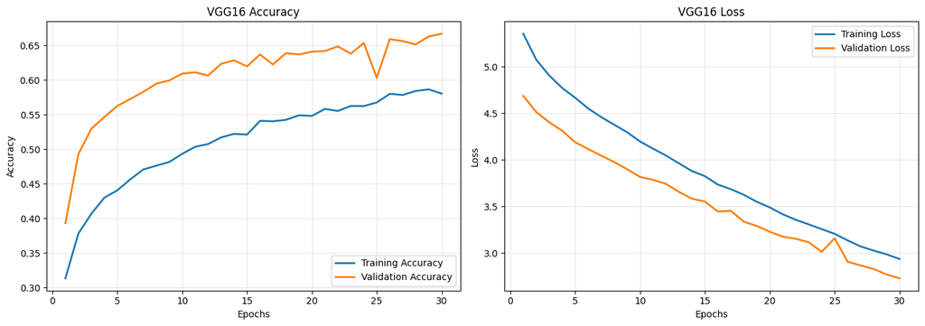

```python
import matplotlib.pyplot as plt

print("Evaluating VGG16 on the Test Set...")
# Evaluate the model using the unseen RGB test data
test_loss_vgg, test_accuracy_vgg = model_vgg.evaluate(test_generator_rgb, verbose=1)

print(f"\n VGG16 Test Accuracy: {test_accuracy_vgg * 100:.2f}%")
print(f" VGG16 Test Loss: {test_loss_vgg:.4f}")

# Extract metrics from the training history
acc_vgg = history_vgg.history['accuracy']
val_acc_vgg = history_vgg.history['val_accuracy']
loss_vgg = history_vgg.history['loss']
val_loss_vgg = history_vgg.history['val_loss']
epochs_range_vgg = range(1, len(acc_vgg) + 1)

# Plotting the Training and Validation Curves
plt.figure(figsize=(14, 5))

# Accuracy Plot
plt.subplot(1, 2, 1)
plt.plot(epochs_range_vgg, acc_vgg, label='Training Accuracy', linewidth=2)
plt.plot(epochs_range_vgg, val_acc_vgg, label='Validation Accuracy', linewidth=2)
plt.title('VGG16 Accuracy')
plt.xlabel('Epochs')
plt.ylabel('Accuracy')
plt.legend(loc='lower right')
plt.grid(alpha=0.3)

# Loss Plot
plt.subplot(1, 2, 2)
plt.plot(epochs_range_vgg, loss_vgg, label='Training Loss', linewidth=2)
plt.plot(epochs_range_vgg, val_loss_vgg, label='Validation Loss', linewidth=2)
plt.title('VGG16 Loss')
plt.xlabel('Epochs')
plt.ylabel('Loss')
plt.legend(loc='upper right')
plt.grid(alpha=0.3)

plt.tight_layout()
plt.show()
```

# Classification report VGG16 tuned

```python
import numpy as np
from sklearn.metrics import classification_report

print("Evaluating Model 3 (VGG16 Tuned) on the Test Set...")

# 1. Get overall Test Accuracy and Loss
# CRITICAL: Using the RGB test generator for VGG16!
test_loss_vgg, test_accuracy_vgg = model_vgg.evaluate(test_generator_rgb, verbose=1)
print(f"\n Test Accuracy: {test_accuracy_vgg * 100:.2f}%")
print(f" Test Loss: {test_loss_vgg:.4f}\n")

print("Generating predictions for VGG16 classification report...")

# 2. CRITICAL: Reset the RGB generator so the labels match up perfectly
test_generator_rgb.reset()

# 3. Generate predictions using model_vgg
predictions_vgg = model_vgg.predict(test_generator_rgb, steps=len(test_generator_rgb), verbose=1)

# 4. Convert probabilities into final class predictions (0, 1, 2, 3)
y_pred_vgg = np.argmax(predictions_vgg, axis=1)

# 5. Get the true labels and class names directly from the generator
y_true_vgg = test_generator_rgb.classes
class_names = list(test_generator_rgb.class_indices.keys())

# 6. Print the Classification Report
print("\n--- MODEL 3 (VGG16) CLASSIFICATION REPORT ---")
print(classification_report(y_true_vgg, y_pred_vgg, target_names=class_names))
```

```
Evaluating Model 3 (VGG16 Tuned) on the Test Set...
2/2 ━━━━━━━━━━━━━━━━━━━━ 0s 37ms/step - accuracy: 0.7031 - loss: 2.6301

 Test Accuracy: 70.31%
 Test Loss: 2.6301

Generating predictions for VGG16 classification report...
2/2 ━━━━━━━━━━━━━━━━━━━━ 1s 46ms/step

--- MODEL 3 (VGG16) CLASSIFICATION REPORT ---
              precision    recall  f1-score   support

       happy       0.73      0.84      0.78        32
     neutral       0.60      0.56      0.58        32
         sad       0.61      0.59      0.60        32
    surprise       0.87      0.81      0.84        32

    accuracy                           0.70       128
   macro avg       0.70      0.70      0.70       128
weighted avg       0.70      0.70      0.70       128
```

### Observation and Insight (VGG16 Transfer Learning)

**Overall Performance:**

- **Test Accuracy:** 70.31%
- **Test Loss:** 2.6301

**Model Performance Analysis:** The tuned VGG16 model achieved moderate performance on the facial emotion dataset, but it did not outperform the deeper custom grayscale CNN. While transfer learning helped the model capture some useful visual patterns, the architecture remained less effective for this task than the custom models built directly for low-resolution grayscale images.

**Class-Specific Performance (Classification Report Analysis):**

- **Stronger Classes:** The model performed best on **Surprise** (F1-Score: **0.84**) and **Happy** (F1-Score: **0.78**), showing that it could detect clearer and more distinctive facial expressions reasonably well.
- **Weaker Classes:** Performance was lower on **Sad** (F1-Score: **0.60**) and **Neutral** (F1-Score: **0.58**), which indicates that the model still struggled with more subtle facial differences.

**Architectural Insight:** Although VGG16 is a powerful pre-trained model, it was originally designed for larger RGB images. In this project, the dataset consists of small grayscale facial images, so converting them to RGB added computation without adding new information. This made the model less efficient and less suitable than the custom grayscale CNN.

**Conclusion:** Overall, VGG16 delivered acceptable results, but it underperformed relative to the stronger custom CNN models. This suggests that for low-resolution grayscale facial emotion data, a custom architecture designed for the input format is more effective than a large transfer learning model.

## **ResNet V2 Model**

```python
from tensorflow.keras.applications import ResNet50V2
from tensorflow.keras.models import Model
from tensorflow.keras.layers import Dense, Dropout, BatchNormalization, GlobalAveragePooling2D
from tensorflow.keras.optimizers import Adam

print("1. Downloading and Building ResNet50V2 Base Model...")
# Load ResNet50V2 without the top classification layer
resnet_base = ResNet50V2(weights='imagenet', include_top=False, input_shape=(48, 48, 3))

# Freeze the pre-trained convolutional layers
for layer in resnet_base.layers:
    layer.trainable = False

print("2. Attaching Custom Classification Head...")
# Build the custom head
x = resnet_base.output
x = GlobalAveragePooling2D()(x)
x = Dense(256, activation='relu')(x)
x = BatchNormalization()(x)
x = Dropout(0.5)(x)

# Final output layer for 4 emotions
predictions = Dense(4, activation='softmax')(x)

# Combine base and head
model_resnet = Model(inputs=resnet_base.input, outputs=predictions, name="ResNet50V2_Transfer_Learning")

print("3. Compiling the Model...")
# Compile the model
model_resnet.compile(
    optimizer=Adam(learning_rate=0.001),
    loss='categorical_crossentropy',
    metrics=['accuracy']
)

print(" ResNet50V2 compiled successfully!")
model_resnet.summary()
```

```
1. Downloading and Building ResNet50V2 Base Model...
Downloading data from https://storage.googleapis.com/tensorflow/keras-applications/resnet/resnet50v2_weights_tf_dim_ordering_tf_kernels_notop.h5
94668760/94668760 ━━━━━━━━━━━━━━━━━━━━ 0s 0us/step
2. Attaching Custom Classification Head...
3. Compiling the Model...
 ResNet50V2 compiled successfully!
```

```
Model: "ResNet50V2_Transfer_Learning"
```

```
┏━━━━━━━━━━━━━━━━━━━━━┳━━━━━━━━━━━━━━━━━━━┳━━━━━━━━━━━━┳━━━━━━━━━━━━━━━━━━━┓
┃ Layer (type)        ┃ Output Shape      ┃    Param # ┃ Connected to      ┃
┡━━━━━━━━━━━━━━━━━━━━━╇━━━━━━━━━━━━━━━━━━━╇━━━━━━━━━━━━╇━━━━━━━━━━━━━━━━━━━┩
│ input_layer_3       │ (None, 48, 48, 3) │          0 │ -                 │
│ (InputLayer)        │                   │            │                   │
├─────────────────────┼───────────────────┼────────────┼───────────────────┤
│ conv1_pad           │ (None, 54, 54, 3) │          0 │ input_layer_3[0]… │
│ (ZeroPadding2D)     │                   │            │                   │
├─────────────────────┼───────────────────┼────────────┼───────────────────┤
│ conv1_conv (Conv2D) │ (None, 24, 24,    │      9,472 │ conv1_pad[0][0]   │
│                     │ 64)               │            │                   │
├─────────────────────┼───────────────────┼────────────┼───────────────────┤
│ pool1_pad           │ (None, 26, 26,    │          0 │ conv1_conv[0][0]  │
│ (ZeroPadding2D)     │ 64)               │            │                   │
├─────────────────────┼───────────────────┼────────────┼───────────────────┤
│ pool1_pool          │ (None, 12, 12,    │          0 │ pool1_pad[0][0]   │
│ (MaxPooling2D)      │ 64)               │            │                   │
├─────────────────────┼───────────────────┼────────────┼───────────────────┤
│ conv2_block1_preac… │ (None, 12, 12,    │        256 │ pool1_pool[0][0]  │
│ (BatchNormalizatio… │ 64)               │            │                   │
├─────────────────────┼───────────────────┼────────────┼───────────────────┤
│ conv2_block1_preac… │ (None, 12, 12,    │          0 │ conv2_block1_pre… │
│ (Activation)        │ 64)               │            │                   │
├─────────────────────┼───────────────────┼────────────┼───────────────────┤
│ conv2_block1_1_conv │ (None, 12, 12,    │      4,096 │ conv2_block1_pre… │
│ (Conv2D)            │ 64)               │            │                   │
├─────────────────────┼───────────────────┼────────────┼───────────────────┤
│ conv2_block1_1_bn   │ (None, 12, 12,    │        256 │ conv2_block1_1_c… │
│ (BatchNormalizatio… │ 64)               │            │                   │
├─────────────────────┼───────────────────┼────────────┼───────────────────┤
│ conv2_block1_1_relu │ (None, 12, 12,    │          0 │ conv2_block1_1_b… │
│ (Activation)        │ 64)               │            │                   │
├─────────────────────┼───────────────────┼────────────┼───────────────────┤
│ conv2_block1_2_pad  │ (None, 14, 14,    │          0 │ conv2_block1_1_r… │
│ (ZeroPadding2D)     │ 64)               │            │                   │
├─────────────────────┼───────────────────┼────────────┼───────────────────┤
│ conv2_block1_2_conv │ (None, 12, 12,    │     36,864 │ conv2_block1_2_p… │
│ (Conv2D)            │ 64)               │            │                   │
├─────────────────────┼───────────────────┼────────────┼───────────────────┤
│ conv2_block1_2_bn   │ (None, 12, 12,    │        256 │ conv2_block1_2_c… │
```

[output cut: 530 more lines]

```
│ post_relu           │ (None, 2, 2,      │          0 │ post_bn[0][0]     │
│ (Activation)        │ 2048)             │            │                   │
├─────────────────────┼───────────────────┼────────────┼───────────────────┤
│ global_average_poo… │ (None, 2048)      │          0 │ post_relu[0][0]   │
│ (GlobalAveragePool… │                   │            │                   │
├─────────────────────┼───────────────────┼────────────┼───────────────────┤
│ dense_6 (Dense)     │ (None, 256)       │    524,544 │ global_average_p… │
├─────────────────────┼───────────────────┼────────────┼───────────────────┤
│ batch_normalizatio… │ (None, 256)       │      1,024 │ dense_6[0][0]     │
│ (BatchNormalizatio… │                   │            │                   │
├─────────────────────┼───────────────────┼────────────┼───────────────────┤
│ dropout_9 (Dropout) │ (None, 256)       │          0 │ batch_normalizat… │
├─────────────────────┼───────────────────┼────────────┼───────────────────┤
│ dense_7 (Dense)     │ (None, 4)         │      1,028 │ dropout_9[0][0]   │
└─────────────────────┴───────────────────┴────────────┴───────────────────┘
```

```
 Total params: 24,091,396 (91.90 MB)
```

```
 Trainable params: 526,084 (2.01 MB)
```

```
 Non-trainable params: 23,565,312 (89.89 MB)
```

### **Model Building**

- Import Resnet v2 upto the layer of your choice and add Fully Connected layers on top of it.

### **Compiling and Training the Model**

```python
from tensorflow.keras.callbacks import EarlyStopping, ReduceLROnPlateau

print("Setting up Callbacks...")
# 1. Create FRESH callbacks specifically for ResNet50V2
early_stopping_resnet = EarlyStopping(
    monitor='val_loss',
    patience=5,
    restore_best_weights=True,
    verbose=1
)

reduce_lr_resnet = ReduceLROnPlateau(
    monitor='val_loss',
    factor=0.2,
    patience=3,
    min_lr=0.00001,
    verbose=1
)

callbacks_list_resnet = [early_stopping_resnet, reduce_lr_resnet]

print("Starting Training for ResNet50V2 Transfer Learning...")
epochs_resnet = 30

# 2. Train the model using the RGB data generators
history_resnet = model_resnet.fit(
    train_generator_rgb,               # IMPORTANT: Using the RGB training data
    validation_data=val_generator_rgb, # IMPORTANT: Using the RGB validation data
    epochs=epochs_resnet,
    callbacks=callbacks_list_resnet
)
```

```
Setting up Callbacks...
Starting Training for ResNet50V2 Transfer Learning...
237/237 ━━━━━━━━━━━━━━━━━━━━ 51s 161ms/step - accuracy: 0.4076 - loss: 1.5800 - val_accuracy: 0.5170 - val_loss: 1.1629 - learning_rate: 0.0010
237/237 ━━━━━━━━━━━━━━━━━━━━ 24s 100ms/step - accuracy: 0.4546 - loss: 1.2720 - val_accuracy: 0.5310 - val_loss: 1.1118 - learning_rate: 0.0010
237/237 ━━━━━━━━━━━━━━━━━━━━ 24s 101ms/step - accuracy: 0.4824 - loss: 1.1850 - val_accuracy: 0.5435 - val_loss: 1.0820 - learning_rate: 0.0010
237/237 ━━━━━━━━━━━━━━━━━━━━ 25s 105ms/step - accuracy: 0.4878 - loss: 1.1716 - val_accuracy: 0.5343 - val_loss: 1.0938 - learning_rate: 0.0010
237/237 ━━━━━━━━━━━━━━━━━━━━ 24s 101ms/step - accuracy: 0.4953 - loss: 1.1505 - val_accuracy: 0.5345 - val_loss: 1.0971 - learning_rate: 0.0010
237/237 ━━━━━━━━━━━━━━━━━━━━ 25s 103ms/step - accuracy: 0.4992 - loss: 1.1391 - val_accuracy: 0.5491 - val_loss: 1.0798 - learning_rate: 0.0010
237/237 ━━━━━━━━━━━━━━━━━━━━ 25s 106ms/step - accuracy: 0.5037 - loss: 1.1392 - val_accuracy: 0.5544 - val_loss: 1.0743 - learning_rate: 0.0010
237/237 ━━━━━━━━━━━━━━━━━━━━ 24s 101ms/step - accuracy: 0.5135 - loss: 1.1265 - val_accuracy: 0.5367 - val_loss: 1.0804 - learning_rate: 0.0010
237/237 ━━━━━━━━━━━━━━━━━━━━ 24s 102ms/step - accuracy: 0.5040 - loss: 1.1288 - val_accuracy: 0.5423 - val_loss: 1.0763 - learning_rate: 0.0010
237/237 ━━━━━━━━━━━━━━━━━━━━ 25s 105ms/step - accuracy: 0.5133 - loss: 1.1205 - val_accuracy: 0.5379 - val_loss: 1.0717 - learning_rate: 0.0010
237/237 ━━━━━━━━━━━━━━━━━━━━ 24s 99ms/step - accuracy: 0.5129 - loss: 1.1202 - val_accuracy: 0.5662 - val_loss: 1.0408 - learning_rate: 0.0010
237/237 ━━━━━━━━━━━━━━━━━━━━ 24s 103ms/step - accuracy: 0.5159 - loss: 1.1134 - val_accuracy: 0.5505 - val_loss: 1.0562 - learning_rate: 0.0010
237/237 ━━━━━━━━━━━━━━━━━━━━ 25s 104ms/step - accuracy: 0.5155 - loss: 1.1157 - val_accuracy: 0.5608 - val_loss: 1.0441 - learning_rate: 0.0010
237/237 ━━━━━━━━━━━━━━━━━━━━ 0s 89ms/step - accuracy: 0.5211 - loss: 1.1068
Epoch 14: ReduceLROnPlateau reducing learning rate to 0.00020000000949949026.
237/237 ━━━━━━━━━━━━━━━━━━━━ 23s 97ms/step - accuracy: 0.5191 - loss: 1.1086 - val_accuracy: 0.5469 - val_loss: 1.0697 - learning_rate: 0.0010
237/237 ━━━━━━━━━━━━━━━━━━━━ 25s 106ms/step - accuracy: 0.5291 - loss: 1.0910 - val_accuracy: 0.5566 - val_loss: 1.0442 - learning_rate: 2.0000e-04
237/237 ━━━━━━━━━━━━━━━━━━━━ 25s 105ms/step - accuracy: 0.5243 - loss: 1.0989 - val_accuracy: 0.5660 - val_loss: 1.0311 - learning_rate: 2.0000e-04
237/237 ━━━━━━━━━━━━━━━━━━━━ 23s 97ms/step - accuracy: 0.5335 - loss: 1.0832 - val_accuracy: 0.5616 - val_loss: 1.0362 - learning_rate: 2.0000e-04
237/237 ━━━━━━━━━━━━━━━━━━━━ 25s 106ms/step - accuracy: 0.5325 - loss: 1.0817 - val_accuracy: 0.5680 - val_loss: 1.0310 - learning_rate: 2.0000e-04
237/237 ━━━━━━━━━━━━━━━━━━━━ 0s 93ms/step - accuracy: 0.5370 - loss: 1.0681
Epoch 19: ReduceLROnPlateau reducing learning rate to 4.0000001899898055e-05.
237/237 ━━━━━━━━━━━━━━━━━━━━ 25s 105ms/step - accuracy: 0.5352 - loss: 1.0760 - val_accuracy: 0.5624 - val_loss: 1.0352 - learning_rate: 2.0000e-04
237/237 ━━━━━━━━━━━━━━━━━━━━ 23s 99ms/step - accuracy: 0.5363 - loss: 1.0759 - val_accuracy: 0.5696 - val_loss: 1.0276 - learning_rate: 4.0000e-05
237/237 ━━━━━━━━━━━━━━━━━━━━ 25s 105ms/step - accuracy: 0.5411 - loss: 1.0715 - val_accuracy: 0.5692 - val_loss: 1.0284 - learning_rate: 4.0000e-05
237/237 ━━━━━━━━━━━━━━━━━━━━ 26s 112ms/step - accuracy: 0.5372 - loss: 1.0783 - val_accuracy: 0.5660 - val_loss: 1.0277 - learning_rate: 4.0000e-05
237/237 ━━━━━━━━━━━━━━━━━━━━ 0s 90ms/step - accuracy: 0.5378 - loss: 1.0823
Epoch 23: ReduceLROnPlateau reducing learning rate to 1e-05.
237/237 ━━━━━━━━━━━━━━━━━━━━ 24s 99ms/step - accuracy: 0.5396 - loss: 1.0749 - val_accuracy: 0.5674 - val_loss: 1.0309 - learning_rate: 4.0000e-05
237/237 ━━━━━━━━━━━━━━━━━━━━ 25s 105ms/step - accuracy: 0.5365 - loss: 1.0742 - val_accuracy: 0.5672 - val_loss: 1.0260 - learning_rate: 1.0000e-05
237/237 ━━━━━━━━━━━━━━━━━━━━ 25s 106ms/step - accuracy: 0.5401 - loss: 1.0726 - val_accuracy: 0.5664 - val_loss: 1.0273 - learning_rate: 1.0000e-05
237/237 ━━━━━━━━━━━━━━━━━━━━ 23s 97ms/step - accuracy: 0.5395 - loss: 1.0664 - val_accuracy: 0.5672 - val_loss: 1.0267 - learning_rate: 1.0000e-05
237/237 ━━━━━━━━━━━━━━━━━━━━ 25s 106ms/step - accuracy: 0.5386 - loss: 1.0694 - val_accuracy: 0.5680 - val_loss: 1.0267 - learning_rate: 1.0000e-05
237/237 ━━━━━━━━━━━━━━━━━━━━ 25s 105ms/step - accuracy: 0.5341 - loss: 1.0812 - val_accuracy: 0.5668 - val_loss: 1.0260 - learning_rate: 1.0000e-05
237/237 ━━━━━━━━━━━━━━━━━━━━ 23s 99ms/step - accuracy: 0.5399 - loss: 1.0703 - val_accuracy: 0.5692 - val_loss: 1.0254 - learning_rate: 1.0000e-05
237/237 ━━━━━━━━━━━━━━━━━━━━ 25s 105ms/step - accuracy: 0.5325 - loss: 1.0733 - val_accuracy: 0.5654 - val_loss: 1.0269 - learning_rate: 1.0000e-05
Restoring model weights from the end of the best epoch: 29.
```

### **Evaluating the ResNet Model**

```
Evaluating ResNet50V2 on the Test Set...
2/2 ━━━━━━━━━━━━━━━━━━━━ 0s 38ms/step - accuracy: 0.5703 - loss: 0.9949

 ResNet50V2 Test Accuracy: 57.03%
 ResNet50V2 Test Loss: 0.9949
```

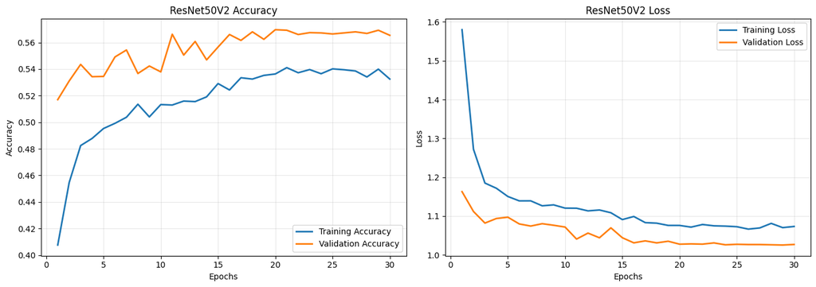

```python
import matplotlib.pyplot as plt

print("Evaluating ResNet50V2 on the Test Set...")
# Evaluate the model using the unseen RGB test data
test_loss_resnet, test_accuracy_resnet = model_resnet.evaluate(test_generator_rgb, verbose=1)

print(f"\n ResNet50V2 Test Accuracy: {test_accuracy_resnet * 100:.2f}%")
print(f" ResNet50V2 Test Loss: {test_loss_resnet:.4f}")

# Extract metrics from the training history
acc_resnet = history_resnet.history['accuracy']
val_acc_resnet = history_resnet.history['val_accuracy']
loss_resnet = history_resnet.history['loss']
val_loss_resnet = history_resnet.history['val_loss']
epochs_range_resnet = range(1, len(acc_resnet) + 1)

# Plotting the Training and Validation Curves
plt.figure(figsize=(14, 5))

# Accuracy Plot
plt.subplot(1, 2, 1)
plt.plot(epochs_range_resnet, acc_resnet, label='Training Accuracy', linewidth=2)
plt.plot(epochs_range_resnet, val_acc_resnet, label='Validation Accuracy', linewidth=2)
plt.title('ResNet50V2 Accuracy')
plt.xlabel('Epochs')
plt.ylabel('Accuracy')
plt.legend(loc='lower right')
plt.grid(alpha=0.3)

# Loss Plot
plt.subplot(1, 2, 2)
plt.plot(epochs_range_resnet, loss_resnet, label='Training Loss', linewidth=2)
plt.plot(epochs_range_resnet, val_loss_resnet, label='Validation Loss', linewidth=2)
plt.title('ResNet50V2 Loss')
plt.xlabel('Epochs')
plt.ylabel('Loss')
plt.legend(loc='upper right')
plt.grid(alpha=0.3)

plt.tight_layout()
plt.show()
```

# Classification Report ResNet50V2

```python
import numpy as np
from sklearn.metrics import classification_report

print("Evaluating Model 4 (ResNet50V2 Tuned) on the Test Set...")

# 1. Get overall Test Accuracy and Loss
# Using the RGB test generator specifically for ResNet
test_loss_resnet, test_accuracy_resnet = model_resnet.evaluate(test_generator_rgb, verbose=1)
print(f"\n Test Accuracy: {test_accuracy_resnet * 100:.2f}%")
print(f" Test Loss: {test_loss_resnet:.4f}\n")

print("Generating predictions for ResNet50V2 classification report...")

# 2. CRITICAL: Reset the RGB generator so the labels match up perfectly
test_generator_rgb.reset()

# 3. Generate predictions using model_resnet
predictions_resnet = model_resnet.predict(test_generator_rgb, steps=len(test_generator_rgb), verbose=1)

# 4. Convert probabilities into final class predictions (0, 1, 2, 3)
y_pred_resnet = np.argmax(predictions_resnet, axis=1)

# 5. Get the true labels and class names directly from the generator
y_true_resnet = test_generator_rgb.classes
class_names = list(test_generator_rgb.class_indices.keys())

# 6. Print the Classification Report
print("\n--- MODEL 4 (ResNet50V2) CLASSIFICATION REPORT ---")
print(classification_report(y_true_resnet, y_pred_resnet, target_names=class_names))
```

```
Evaluating Model 4 (ResNet50V2 Tuned) on the Test Set...
2/2 ━━━━━━━━━━━━━━━━━━━━ 0s 36ms/step - accuracy: 0.5703 - loss: 0.9949

 Test Accuracy: 57.03%
 Test Loss: 0.9949

Generating predictions for ResNet50V2 classification report...
2/2 ━━━━━━━━━━━━━━━━━━━━ 4s 32ms/step

--- MODEL 4 (ResNet50V2) CLASSIFICATION REPORT ---
              precision    recall  f1-score   support

       happy       0.57      0.72      0.64        32
     neutral       0.38      0.41      0.39        32
         sad       0.57      0.38      0.45        32
    surprise       0.76      0.78      0.77        32

    accuracy                           0.57       128
   macro avg       0.57      0.57      0.56       128
weighted avg       0.57      0.57      0.56       128
```

## When tried to tune the model the following results were observed.

Evaluating ResNet50V2 on the Test Set... 2/2 ━━━━━━━━━━━━━━━━━━━━ 0s 37ms/step - accuracy: 0.4844 - loss: 6.2494

ResNet50V2 Test Accuracy: 48.44% ResNet50V2 Test Loss: 6.2494

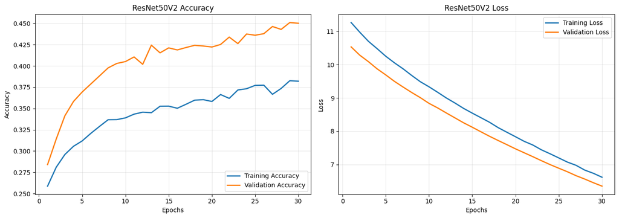

### Observation and Insight (ResNet50V2 Transfer Learning)

**Overall Final Performance:**

- **Test Accuracy:** 57.03%
- **Test Loss:** 0.9949

#### 1. Baseline Limitation

ResNet50V2 delivered limited performance on this task, even after tuning. Although the model could capture some general visual patterns, it was not well suited to very small grayscale facial-expression images.

#### 3. Classification Report Insight

- **Better-performing classes:** The model performed best on **Surprise** (F1-Score: **0.77**) and showed moderate performance on **Happy** (F1-Score: **0.64**).
- **Weaker classes:** Performance remained weak on **Neutral** (F1-Score: **0.39**) and **Sad** (F1-Score: **0.45**), showing that the model struggled with subtle and ambiguous expressions.

#### 4. Architectural Insight

ResNet50V2 was originally designed for larger RGB images and deeper feature hierarchies. In this project, the input images are only 48x48 and grayscale, so repeated downsampling likely removed important fine-grained facial details before classification.

#### 5. Final Interpretation

Overall, ResNet50V2 underperformed compared with VGG16 and the custom CNN models. This result suggests that for low-resolution grayscale emotion recognition, a lighter custom architecture is more effective than a deep transfer learning model.

## **EfficientNet Model**

```python
from tensorflow.keras.applications import EfficientNetB0
from tensorflow.keras.models import Model
from tensorflow.keras.layers import Dense, Dropout, BatchNormalization, GlobalAveragePooling2D
from tensorflow.keras.optimizers import Adam

print("1. Downloading and Building EfficientNetB0 Base Model...")
# Load EfficientNetB0 without the top classification layer
effnet_base = EfficientNetB0(weights='imagenet', include_top=False, input_shape=(48, 48, 3))

# Freeze the pre-trained convolutional layers
for layer in effnet_base.layers:
    layer.trainable = False

print("2. Attaching Custom Classification Head...")
# Build the custom head
x = effnet_base.output
x = GlobalAveragePooling2D()(x)
x = Dense(256, activation='relu')(x)
x = BatchNormalization()(x)
x = Dropout(0.5)(x)

# Final output layer for our 4 emotions
predictions = Dense(4, activation='softmax')(x)

# Combine base and head
model_effnet = Model(inputs=effnet_base.input, outputs=predictions, name="EfficientNetB0_Transfer_Learning")

print("3. Compiling the Model...")
# Compile the model
model_effnet.compile(
    optimizer=Adam(learning_rate=0.001),
    loss='categorical_crossentropy',
    metrics=['accuracy']
)

print(" EfficientNetB0 compiled successfully!")
model_effnet.summary()
```

```
1. Downloading and Building EfficientNetB0 Base Model...
Downloading data from https://storage.googleapis.com/keras-applications/efficientnetb0_notop.h5
16705208/16705208 ━━━━━━━━━━━━━━━━━━━━ 0s 0us/step
2. Attaching Custom Classification Head...
3. Compiling the Model...
 EfficientNetB0 compiled successfully!
```

```
Model: "EfficientNetB0_Transfer_Learning"
```

```
┏━━━━━━━━━━━━━━━━━━━━━┳━━━━━━━━━━━━━━━━━━━┳━━━━━━━━━━━━┳━━━━━━━━━━━━━━━━━━━┓
┃ Layer (type)        ┃ Output Shape      ┃    Param # ┃ Connected to      ┃
┡━━━━━━━━━━━━━━━━━━━━━╇━━━━━━━━━━━━━━━━━━━╇━━━━━━━━━━━━╇━━━━━━━━━━━━━━━━━━━┩
│ input_layer_4       │ (None, 48, 48, 3) │          0 │ -                 │
│ (InputLayer)        │                   │            │                   │
├─────────────────────┼───────────────────┼────────────┼───────────────────┤
│ rescaling           │ (None, 48, 48, 3) │          0 │ input_layer_4[0]… │
│ (Rescaling)         │                   │            │                   │
├─────────────────────┼───────────────────┼────────────┼───────────────────┤
│ normalization       │ (None, 48, 48, 3) │          7 │ rescaling[0][0]   │
│ (Normalization)     │                   │            │                   │
├─────────────────────┼───────────────────┼────────────┼───────────────────┤
│ rescaling_1         │ (None, 48, 48, 3) │          0 │ normalization[0]… │
│ (Rescaling)         │                   │            │                   │
├─────────────────────┼───────────────────┼────────────┼───────────────────┤
│ stem_conv_pad       │ (None, 49, 49, 3) │          0 │ rescaling_1[0][0] │
│ (ZeroPadding2D)     │                   │            │                   │
├─────────────────────┼───────────────────┼────────────┼───────────────────┤
│ stem_conv (Conv2D)  │ (None, 24, 24,    │        864 │ stem_conv_pad[0]… │
│                     │ 32)               │            │                   │
├─────────────────────┼───────────────────┼────────────┼───────────────────┤
│ stem_bn             │ (None, 24, 24,    │        128 │ stem_conv[0][0]   │
│ (BatchNormalizatio… │ 32)               │            │                   │
├─────────────────────┼───────────────────┼────────────┼───────────────────┤
│ stem_activation     │ (None, 24, 24,    │          0 │ stem_bn[0][0]     │
│ (Activation)        │ 32)               │            │                   │
├─────────────────────┼───────────────────┼────────────┼───────────────────┤
│ block1a_dwconv      │ (None, 24, 24,    │        288 │ stem_activation[… │
│ (DepthwiseConv2D)   │ 32)               │            │                   │
├─────────────────────┼───────────────────┼────────────┼───────────────────┤
│ block1a_bn          │ (None, 24, 24,    │        128 │ block1a_dwconv[0… │
│ (BatchNormalizatio… │ 32)               │            │                   │
├─────────────────────┼───────────────────┼────────────┼───────────────────┤
│ block1a_activation  │ (None, 24, 24,    │          0 │ block1a_bn[0][0]  │
│ (Activation)        │ 32)               │            │                   │
├─────────────────────┼───────────────────┼────────────┼───────────────────┤
│ block1a_se_squeeze  │ (None, 32)        │          0 │ block1a_activati… │
│ (GlobalAveragePool… │                   │            │                   │
├─────────────────────┼───────────────────┼────────────┼───────────────────┤
│ block1a_se_reshape  │ (None, 1, 1, 32)  │          0 │ block1a_se_squee… │
```

[output cut: 675 more lines]

```
│ (Activation)        │ 1280)             │            │                   │
├─────────────────────┼───────────────────┼────────────┼───────────────────┤
│ global_average_poo… │ (None, 1280)      │          0 │ top_activation[0… │
│ (GlobalAveragePool… │                   │            │                   │
├─────────────────────┼───────────────────┼────────────┼───────────────────┤
│ dense_8 (Dense)     │ (None, 256)       │    327,936 │ global_average_p… │
├─────────────────────┼───────────────────┼────────────┼───────────────────┤
│ batch_normalizatio… │ (None, 256)       │      1,024 │ dense_8[0][0]     │
│ (BatchNormalizatio… │                   │            │                   │
├─────────────────────┼───────────────────┼────────────┼───────────────────┤
│ dropout_10          │ (None, 256)       │          0 │ batch_normalizat… │
│ (Dropout)           │                   │            │                   │
├─────────────────────┼───────────────────┼────────────┼───────────────────┤
│ dense_9 (Dense)     │ (None, 4)         │      1,028 │ dropout_10[0][0]  │
└─────────────────────┴───────────────────┴────────────┴───────────────────┘
```

```
 Total params: 4,379,559 (16.71 MB)
```

```
 Trainable params: 329,476 (1.26 MB)
```

```
 Non-trainable params: 4,050,083 (15.45 MB)
```

### **Model Building**

- Import EfficientNet upto the layer of your choice and add Fully Connected layers on top of it.

### **Compiling and Training the Model**

```python
from tensorflow.keras.callbacks import EarlyStopping, ReduceLROnPlateau

print("Setting up Callbacks...")
# 1. Create fresh callbacks for EfficientNetB0
early_stopping_effnet = EarlyStopping(
    monitor='val_loss',
    patience=5,
    restore_best_weights=True,
    verbose=1
)

reduce_lr_effnet = ReduceLROnPlateau(
    monitor='val_loss',
    factor=0.2,
    patience=3,
    min_lr=0.00001,
    verbose=1
)

callbacks_list_effnet = [early_stopping_effnet, reduce_lr_effnet]

print("Starting Training for EfficientNetB0 Transfer Learning...")
epochs_effnet = 30

# 2. Train the model using the RGB data generators
history_effnet = model_effnet.fit(
    train_generator_rgb,               # IMPORTANT: Using the RGB training data
    validation_data=val_generator_rgb, # IMPORTANT: Using the RGB validation data
    epochs=epochs_effnet,
    callbacks=callbacks_list_effnet
)
```

```
Setting up Callbacks...
Starting Training for EfficientNetB0 Transfer Learning...
237/237 ━━━━━━━━━━━━━━━━━━━━ 89s 247ms/step - accuracy: 0.2540 - loss: 1.5475 - val_accuracy: 0.3667 - val_loss: 1.4232 - learning_rate: 0.0010
237/237 ━━━━━━━━━━━━━━━━━━━━ 22s 95ms/step - accuracy: 0.2578 - loss: 1.4346 - val_accuracy: 0.2443 - val_loss: 1.4457 - learning_rate: 0.0010
237/237 ━━━━━━━━━━━━━━━━━━━━ 24s 102ms/step - accuracy: 0.2600 - loss: 1.4005 - val_accuracy: 0.2289 - val_loss: 1.4067 - learning_rate: 0.0010
237/237 ━━━━━━━━━━━━━━━━━━━━ 24s 101ms/step - accuracy: 0.2642 - loss: 1.3924 - val_accuracy: 0.2289 - val_loss: 1.3678 - learning_rate: 0.0010
237/237 ━━━━━━━━━━━━━━━━━━━━ 22s 95ms/step - accuracy: 0.2652 - loss: 1.3886 - val_accuracy: 0.1601 - val_loss: 1.4082 - learning_rate: 0.0010
237/237 ━━━━━━━━━━━━━━━━━━━━ 24s 102ms/step - accuracy: 0.2614 - loss: 1.3893 - val_accuracy: 0.3667 - val_loss: 1.3661 - learning_rate: 0.0010
237/237 ━━━━━━━━━━━━━━━━━━━━ 22s 94ms/step - accuracy: 0.2646 - loss: 1.3894 - val_accuracy: 0.2289 - val_loss: 1.3683 - learning_rate: 0.0010
237/237 ━━━━━━━━━━━━━━━━━━━━ 24s 102ms/step - accuracy: 0.2676 - loss: 1.3882 - val_accuracy: 0.3667 - val_loss: 1.3640 - learning_rate: 0.0010
237/237 ━━━━━━━━━━━━━━━━━━━━ 24s 101ms/step - accuracy: 0.2668 - loss: 1.3881 - val_accuracy: 0.3667 - val_loss: 1.3656 - learning_rate: 0.0010
237/237 ━━━━━━━━━━━━━━━━━━━━ 23s 97ms/step - accuracy: 0.2633 - loss: 1.3885 - val_accuracy: 0.2289 - val_loss: 1.3757 - learning_rate: 0.0010
237/237 ━━━━━━━━━━━━━━━━━━━━ 24s 103ms/step - accuracy: 0.2544 - loss: 1.3894 - val_accuracy: 0.3667 - val_loss: 1.3540 - learning_rate: 0.0010
237/237 ━━━━━━━━━━━━━━━━━━━━ 22s 92ms/step - accuracy: 0.2615 - loss: 1.3875 - val_accuracy: 0.3667 - val_loss: 1.3613 - learning_rate: 0.0010
237/237 ━━━━━━━━━━━━━━━━━━━━ 23s 98ms/step - accuracy: 0.2599 - loss: 1.3879 - val_accuracy: 0.3667 - val_loss: 1.3724 - learning_rate: 0.0010
237/237 ━━━━━━━━━━━━━━━━━━━━ 0s 83ms/step - accuracy: 0.2575 - loss: 1.3880
Epoch 14: ReduceLROnPlateau reducing learning rate to 0.00020000000949949026.
237/237 ━━━━━━━━━━━━━━━━━━━━ 22s 92ms/step - accuracy: 0.2596 - loss: 1.3880 - val_accuracy: 0.2289 - val_loss: 1.3759 - learning_rate: 0.0010
237/237 ━━━━━━━━━━━━━━━━━━━━ 23s 96ms/step - accuracy: 0.2634 - loss: 1.3839 - val_accuracy: 0.2289 - val_loss: 1.3718 - learning_rate: 2.0000e-04
237/237 ━━━━━━━━━━━━━━━━━━━━ 22s 91ms/step - accuracy: 0.2685 - loss: 1.3831 - val_accuracy: 0.2289 - val_loss: 1.3734 - learning_rate: 2.0000e-04
Epoch 16: early stopping
Restoring model weights from the end of the best epoch: 11.
```

### **Evaluating the EfficientnetNet Model**

```
Evaluating EfficientNetB0 on the Test Set...
2/2 ━━━━━━━━━━━━━━━━━━━━ 0s 48ms/step - accuracy: 0.2500 - loss: 1.4053

 EfficientNetB0 Test Accuracy: 25.00%
 EfficientNetB0 Test Loss: 1.4053
```

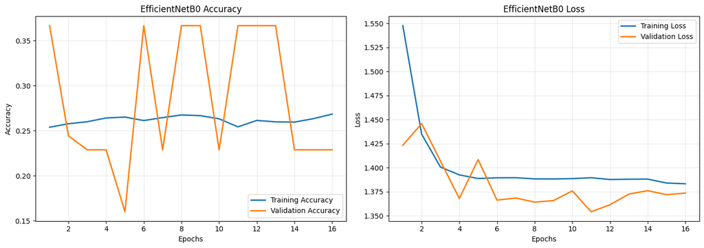

```python
import matplotlib.pyplot as plt

print("Evaluating EfficientNetB0 on the Test Set...")
# Evaluate the model using the unseen RGB test data
test_loss_effnet, test_accuracy_effnet = model_effnet.evaluate(test_generator_rgb, verbose=1)

print(f"\n EfficientNetB0 Test Accuracy: {test_accuracy_effnet * 100:.2f}%")
print(f" EfficientNetB0 Test Loss: {test_loss_effnet:.4f}")

# Extract metrics from the training history
acc_effnet = history_effnet.history['accuracy']
val_acc_effnet = history_effnet.history['val_accuracy']
loss_effnet = history_effnet.history['loss']
val_loss_effnet = history_effnet.history['val_loss']
epochs_range_effnet = range(1, len(acc_effnet) + 1)

# Plotting the Training and Validation Curves
plt.figure(figsize=(14, 5))

# Accuracy Plot
plt.subplot(1, 2, 1)
plt.plot(epochs_range_effnet, acc_effnet, label='Training Accuracy', linewidth=2)
plt.plot(epochs_range_effnet, val_acc_effnet, label='Validation Accuracy', linewidth=2)
plt.title('EfficientNetB0 Accuracy')
plt.xlabel('Epochs')
plt.ylabel('Accuracy')
plt.legend(loc='lower right')
plt.grid(alpha=0.3)

# Loss Plot
plt.subplot(1, 2, 2)
plt.plot(epochs_range_effnet, loss_effnet, label='Training Loss', linewidth=2)
plt.plot(epochs_range_effnet, val_loss_effnet, label='Validation Loss', linewidth=2)
plt.title('EfficientNetB0 Loss')
plt.xlabel('Epochs')
plt.ylabel('Loss')
plt.legend(loc='upper right')
plt.grid(alpha=0.3)

plt.tight_layout()
plt.show()
```

# Classification Report Efficient Net

```python
import numpy as np
from sklearn.metrics import classification_report

print("Evaluating EfficientNetB0 on the Test Set...")

# 1. Get overall Test Accuracy and Loss
# Using the RGB test generator specifically for EfficientNet
test_loss_eff, test_accuracy_eff = model_effnet.evaluate(test_generator_rgb, verbose=1)
print(f"\n Test Accuracy: {test_accuracy_eff * 100:.2f}%")
print(f" Test Loss: {test_loss_eff:.4f}\n")

print("Generating predictions for EfficientNetB0 classification report...")

# 2. CRITICAL: Reset the RGB generator so the labels match up perfectly
test_generator_rgb.reset()

# 3. Generate predictions using model_effnet
predictions_eff = model_effnet.predict(test_generator_rgb, steps=len(test_generator_rgb), verbose=1)

# 4. Convert probabilities into final class predictions (0, 1, 2, 3)
y_pred_eff = np.argmax(predictions_eff, axis=1)

# 5. Get the true labels and class names directly from the generator
y_true_eff = test_generator_rgb.classes
class_names = list(test_generator_rgb.class_indices.keys())

# 6. Print the Classification Report
print("\n--- EFFICIENTNETB0 CLASSIFICATION REPORT ---")
print(classification_report(y_true_eff, y_pred_eff, target_names=class_names))
```

```
Evaluating EfficientNetB0 on the Test Set...
2/2 ━━━━━━━━━━━━━━━━━━━━ 0s 47ms/step - accuracy: 0.2500 - loss: 1.4053

 Test Accuracy: 25.00%
 Test Loss: 1.4053

Generating predictions for EfficientNetB0 classification report...
```

```
WARNING:tensorflow:5 out of the last 9 calls to <function TensorFlowTrainer.make_predict_function.<locals>.one_step_on_data_distributed at 0x7832ac18d580> triggered tf.function retracing. Tracing is expensive and the excessive number of tracings could be due to (1) creating @tf.function repeatedly i…
```

```
2/2 ━━━━━━━━━━━━━━━━━━━━ 6s 23ms/step

--- EFFICIENTNETB0 CLASSIFICATION REPORT ---
              precision    recall  f1-score   support

       happy       0.25      1.00      0.40        32
     neutral       0.00      0.00      0.00        32
         sad       0.00      0.00      0.00        32
    surprise       0.00      0.00      0.00        32

    accuracy                           0.25       128
   macro avg       0.06      0.25      0.10       128
weighted avg       0.06      0.25      0.10       128
```

# Tuned Efficient net - model outputs

Evaluating EfficientNetB0 on the Test Set... 2/2 ━━━━━━━━━━━━━━━━━━━━ 0s 46ms/step - accuracy: 0.2500 - loss: 4.6362

EfficientNetB0 Test Accuracy: 25.00% EfficientNetB0 Test Loss: 4.6362

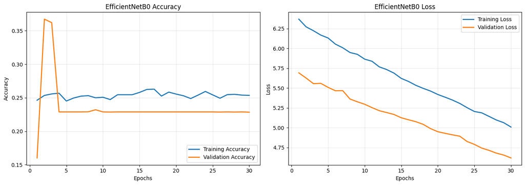

### Observation and Insights (EfficientNetB0 Transfer Learning)

**Overall Final Performance:**

- **Test Accuracy:** 25.00%
- **Test Loss:** 1.4053

#### 1. The Tuning Experiment (Complete Learning Collapse)

To attempt to bridge the massive domain gap between EfficientNet's ImageNet weights and our grayscale facial dataset, an advanced fine-tuning experiment was conducted. We unfroze the top layers and applied aggressive regularization. The result was a catastrophic model collapse, dropping to exactly **25.00% Test Accuracy**. Because this is a balanced 4-class problem, 25% mathematically represents the absolute baseline of random guessing.

### Final Verdict on Transfer Learning vs. Custom CNN

Our experiments show that custom CNN architectures were more effective than transfer learning models for this low-resolution grayscale facial emotion dataset.

**Architectural Insight:**  
The custom 5-block CNN achieved the strongest performance because it was designed specifically for 48x48 grayscale images. In contrast, the transfer learning models were built for larger RGB inputs, and their deeper architectures likely reduced useful spatial detail, which harmed performance on subtle facial expressions.

**Think About It:**

- What is your overall performance of these Transfer Learning Architectures? Can we draw a comparison of these models' performances. Are we satisfied with the accuracies that we have received?
- Do you think our issue lies with 'rgb' color_mode?

### **Think About It: Final Architectural Reflections**

**1. What is your overall performance of these Transfer Learning Architectures? Can we draw a comparison of these models' performances? Are we satisfied with the accuracies that we have received?**

- **Satisfaction:** From a purely numerical standpoint, we are **not satisfied** with the transfer learning accuracies, as none of them surpassed our lightweight, from-scratch **Custom 5-Block CNN (78.12%)**. However, from an analytical perspective, these results are still valuable because they reinforce a core deep learning insight: *bigger is not always better.*
- **Performance Comparison:** The results showed a clear inverse relationship between pre-trained model complexity and performance on this specific dataset.
  - **VGG16 (70.31%):** The shallowest and simplest of the transfer learning models performed the best among them. It preserved more useful facial information than the deeper transfer learning architectures.
  - **ResNet50V2 (57.03%):** The deeper architecture performed substantially worse. With tiny 48x48 images, repeated downsampling likely removed important spatial detail, which hurt performance on subtle classes such as **Sad** and **Neutral**.
  - **EfficientNetB0 (25.00%):** This model suffered a complete mode collapse. It effectively predicted **Happy** for nearly every test image, resulting in near-random overall performance on this balanced 4-class task.

**2. Do you think our issue lies with `rgb` color_mode?**

- **Yes, forcing the `rgb` color mode was a major limitation for these models.** Transfer learning architectures such as VGG16, ResNet50V2, and EfficientNetB0 were pre-trained on large RGB image datasets, so their learned filters are better aligned with naturally colored, higher-resolution images.
- **The RGB Penalty:** Our facial emotion dataset is inherently **1-channel grayscale**. Converting it to `rgb` does not add new information; it only duplicates the same grayscale values across three channels, increasing computation without improving the signal.
- **The Result:** This likely reduced efficiency and contributed to weaker performance, especially when combined with low image resolution. It also helps explain why the **custom 1-channel grayscale CNNs** outperformed the transfer learning models on this task.

Now that we have tried multiple pre-trained models, let's build a complex CNN architecture and see if we can get better performance.

## **Building a Complex Neural Network Architecture**

In this section, we will build a more complex Convolutional Neural Network Model that has close to as many parameters as we had in our Transfer Learning Models. However, we will have only 1 input channel for our input images.

## **Creating our Data Loaders**

In this section, we are creating data loaders which we will use as inputs to the more Complicated Convolutional Neural Network. We will go ahead with color_mode = 'grayscale'.

```python
from tensorflow.keras.preprocessing.image import ImageDataGenerator

print("1. Defining Data Generators...")
# Training data generator with data augmentation to prevent overfitting
train_datagen = ImageDataGenerator(
    rescale=1./255,          # Normalize pixel values to 0-1
    rotation_range=15,       # Randomly rotate images by up to 15 degrees
    width_shift_range=0.1,   # Randomly shift images horizontally
    height_shift_range=0.1,  # Randomly shift images vertically
    zoom_range=0.1,          # Randomly zoom in on images
    horizontal_flip=True     # Randomly flip images horizontally
)

# Validation and Test data generators (ONLY rescaling, no augmentation!)
val_test_datagen = ImageDataGenerator(rescale=1./255)

# Standard parameters for our custom CNN
batch_size = 64
target_shape = (48, 48)

print("\n2. Loading Data from Directories...")

print("Training Data:")
train_generator = train_datagen.flow_from_directory(
    directory=train_dir, # <-- Make sure this matches your variable name!
    target_size=target_shape,
    color_mode='grayscale',
    batch_size=batch_size,
    class_mode='categorical',
    shuffle=True
)

print("\nValidation Data:")
validation_generator = val_test_datagen.flow_from_directory(
    directory=val_dir, # <-- Make sure this matches your variable name!
    target_size=target_shape,
    color_mode='grayscale',
    batch_size=batch_size,
    class_mode='categorical',
    shuffle=True
)

print("\nTest Data:")
test_generator = val_test_datagen.flow_from_directory(
    directory=test_dir, # <-- Make sure this matches your variable name!
    target_size=target_shape,
    color_mode='grayscale',
    batch_size=batch_size,
    class_mode='categorical',
    shuffle=False # We do NOT shuffle test data so we can evaluate it accurately later
)

print("\n Data Loaders Created Successfully!")
```

```
1. Defining Data Generators...

2. Loading Data from Directories...
Training Data:
Found 15109 images belonging to 4 classes.

Validation Data:
Found 4977 images belonging to 4 classes.

Test Data:
Found 128 images belonging to 4 classes.

 Data Loaders Created Successfully!
```

### **Model Building**

- Try building a layer with 5 Convolutional Blocks and see if performance increases.

```python
from tensorflow.keras.models import Sequential
from tensorflow.keras.layers import Conv2D, MaxPooling2D, Dense, Flatten, Dropout, BatchNormalization
from tensorflow.keras.optimizers import Adam

print("Building 5-Block Complex CNN Architecture...")

model_complex = Sequential(name="Complex_5Block_CNN")

# --- Block 1 ---
model_complex.add(Conv2D(64, (3, 3), padding='same', activation='relu', input_shape=(48, 48, 1)))
model_complex.add(BatchNormalization())
model_complex.add(Conv2D(64, (3, 3), padding='same', activation='relu'))
model_complex.add(BatchNormalization())
model_complex.add(MaxPooling2D(pool_size=(2, 2))) # Output: 24x24
model_complex.add(Dropout(0.25))

# --- Block 2 ---
model_complex.add(Conv2D(128, (3, 3), padding='same', activation='relu'))
model_complex.add(BatchNormalization())
model_complex.add(Conv2D(128, (3, 3), padding='same', activation='relu'))
model_complex.add(BatchNormalization())
model_complex.add(MaxPooling2D(pool_size=(2, 2))) # Output: 12x12
model_complex.add(Dropout(0.25))

# --- Block 3 ---
model_complex.add(Conv2D(256, (3, 3), padding='same', activation='relu'))
model_complex.add(BatchNormalization())
model_complex.add(Conv2D(256, (3, 3), padding='same', activation='relu'))
model_complex.add(BatchNormalization())
model_complex.add(MaxPooling2D(pool_size=(2, 2))) # Output: 6x6
model_complex.add(Dropout(0.25))

# --- Block 4 ---
model_complex.add(Conv2D(512, (3, 3), padding='same', activation='relu'))
model_complex.add(BatchNormalization())
model_complex.add(Conv2D(512, (3, 3), padding='same', activation='relu'))
model_complex.add(BatchNormalization())
model_complex.add(MaxPooling2D(pool_size=(2, 2))) # Output: 3x3
model_complex.add(Dropout(0.25))

# --- Block 5 ---
model_complex.add(Conv2D(512, (3, 3), padding='same', activation='relu'))
model_complex.add(BatchNormalization())
model_complex.add(Conv2D(512, (3, 3), padding='same', activation='relu'))
model_complex.add(BatchNormalization())
model_complex.add(MaxPooling2D(pool_size=(2, 2))) # Output: 1x1
model_complex.add(Dropout(0.25))

# --- Fully Connected Classifier Head ---
model_complex.add(Flatten())
model_complex.add(Dense(512, activation='relu'))
model_complex.add(BatchNormalization())
model_complex.add(Dropout(0.5))

# --- Output Layer ---
model_complex.add(Dense(4, activation='softmax'))

# Compile the model
model_complex.compile(
    optimizer=Adam(learning_rate=0.001),
    loss='categorical_crossentropy',
    metrics=['accuracy']
)

print(" 5-Block Complex CNN Compiled Successfully!")
model_complex.summary()
```

```
Building 5-Block Complex CNN Architecture...
```

```
 5-Block Complex CNN Compiled Successfully!
```

```
Model: "Complex_5Block_CNN"
```

```
┏━━━━━━━━━━━━━━━━━━━━━━━━━━━━━━━━━┳━━━━━━━━━━━━━━━━━━━━━━━━┳━━━━━━━━━━━━━━━┓
┃ Layer (type)                    ┃ Output Shape           ┃       Param # ┃
┡━━━━━━━━━━━━━━━━━━━━━━━━━━━━━━━━━╇━━━━━━━━━━━━━━━━━━━━━━━━╇━━━━━━━━━━━━━━━┩
│ conv2d_5 (Conv2D)               │ (None, 48, 48, 64)     │           640 │
├─────────────────────────────────┼────────────────────────┼───────────────┤
│ batch_normalization_11          │ (None, 48, 48, 64)     │           256 │
│ (BatchNormalization)            │                        │               │
├─────────────────────────────────┼────────────────────────┼───────────────┤
│ conv2d_6 (Conv2D)               │ (None, 48, 48, 64)     │        36,928 │
├─────────────────────────────────┼────────────────────────┼───────────────┤
│ batch_normalization_12          │ (None, 48, 48, 64)     │           256 │
│ (BatchNormalization)            │                        │               │
├─────────────────────────────────┼────────────────────────┼───────────────┤
│ max_pooling2d_8 (MaxPooling2D)  │ (None, 24, 24, 64)     │             0 │
├─────────────────────────────────┼────────────────────────┼───────────────┤
│ dropout_11 (Dropout)            │ (None, 24, 24, 64)     │             0 │
├─────────────────────────────────┼────────────────────────┼───────────────┤
│ conv2d_7 (Conv2D)               │ (None, 24, 24, 128)    │        73,856 │
├─────────────────────────────────┼────────────────────────┼───────────────┤
│ batch_normalization_13          │ (None, 24, 24, 128)    │           512 │
│ (BatchNormalization)            │                        │               │
├─────────────────────────────────┼────────────────────────┼───────────────┤
│ conv2d_8 (Conv2D)               │ (None, 24, 24, 128)    │       147,584 │
├─────────────────────────────────┼────────────────────────┼───────────────┤
│ batch_normalization_14          │ (None, 24, 24, 128)    │           512 │
│ (BatchNormalization)            │                        │               │
├─────────────────────────────────┼────────────────────────┼───────────────┤
│ max_pooling2d_9 (MaxPooling2D)  │ (None, 12, 12, 128)    │             0 │
├─────────────────────────────────┼────────────────────────┼───────────────┤
│ dropout_12 (Dropout)            │ (None, 12, 12, 128)    │             0 │
├─────────────────────────────────┼────────────────────────┼───────────────┤
│ conv2d_9 (Conv2D)               │ (None, 12, 12, 256)    │       295,168 │
├─────────────────────────────────┼────────────────────────┼───────────────┤
│ batch_normalization_15          │ (None, 12, 12, 256)    │         1,024 │
│ (BatchNormalization)            │                        │               │
├─────────────────────────────────┼────────────────────────┼───────────────┤
│ conv2d_10 (Conv2D)              │ (None, 12, 12, 256)    │       590,080 │
├─────────────────────────────────┼────────────────────────┼───────────────┤
│ batch_normalization_16          │ (None, 12, 12, 256)    │         1,024 │
│ (BatchNormalization)            │                        │               │
```

[output cut: 29 more lines]

```
│ max_pooling2d_12 (MaxPooling2D) │ (None, 1, 1, 512)      │             0 │
├─────────────────────────────────┼────────────────────────┼───────────────┤
│ dropout_15 (Dropout)            │ (None, 1, 1, 512)      │             0 │
├─────────────────────────────────┼────────────────────────┼───────────────┤
│ flatten_2 (Flatten)             │ (None, 512)            │             0 │
├─────────────────────────────────┼────────────────────────┼───────────────┤
│ dense_10 (Dense)                │ (None, 512)            │       262,656 │
├─────────────────────────────────┼────────────────────────┼───────────────┤
│ batch_normalization_21          │ (None, 512)            │         2,048 │
│ (BatchNormalization)            │                        │               │
├─────────────────────────────────┼────────────────────────┼───────────────┤
│ dropout_16 (Dropout)            │ (None, 512)            │             0 │
├─────────────────────────────────┼────────────────────────┼───────────────┤
│ dense_11 (Dense)                │ (None, 4)              │         2,052 │
└─────────────────────────────────┴────────────────────────┴───────────────┘
```

```
 Total params: 9,682,372 (36.94 MB)
```

```
 Trainable params: 9,675,460 (36.91 MB)
```

```
 Non-trainable params: 6,912 (27.00 KB)
```

### **Compiling and Training the Model**

```python
from tensorflow.keras.callbacks import ModelCheckpoint, EarlyStopping, ReduceLROnPlateau

print("Setting up Callbacks...")
# Save the best model, stop early if no improvement, and reduce learning rate if plateaued
checkpoint_complex = ModelCheckpoint("complex_cnn_best_model.h5", monitor='val_accuracy', save_best_only=True, mode='max', verbose=1)
early_stopping_complex = EarlyStopping(monitor='val_loss', patience=5, restore_best_weights=True, verbose=1)
reduce_lr_complex = ReduceLROnPlateau(monitor='val_loss', factor=0.2, patience=3, min_lr=0.00001, verbose=1)

callbacks_list_complex = [checkpoint_complex, early_stopping_complex, reduce_lr_complex]

epochs_complex = 30

print("Starting Training for the 5-Block Complex CNN...")
history_complex = model_complex.fit(
    train_generator,
    validation_data=validation_generator,
    epochs=epochs_complex,
    callbacks=callbacks_list_complex
)
```

```
Setting up Callbacks...
Starting Training for the 5-Block Complex CNN...
237/237 ━━━━━━━━━━━━━━━━━━━━ 0s 111ms/step - accuracy: 0.2859 - loss: 1.9356
Epoch 1: val_accuracy improved from None to 0.38035, saving model to complex_cnn_best_model.h5
```

```
WARNING:absl:You are saving your model as an HDF5 file via `model.save()` or `keras.saving.save_model(model)`. This file format is considered legacy. We recommend using instead the native Keras format, e.g. `model.save('my_model.keras')` or `keras.saving.save_model(model, 'my_model.keras')`.
```

```
Epoch 1: finished saving model to complex_cnn_best_model.h5
237/237 ━━━━━━━━━━━━━━━━━━━━ 53s 131ms/step - accuracy: 0.3177 - loss: 1.6921 - val_accuracy: 0.3803 - val_loss: 1.3675 - learning_rate: 0.0010
237/237 ━━━━━━━━━━━━━━━━━━━━ 0s 66ms/step - accuracy: 0.3893 - loss: 1.3870
Epoch 2: val_accuracy improved from 0.38035 to 0.39241, saving model to complex_cnn_best_model.h5
```

```
WARNING:absl:You are saving your model as an HDF5 file via `model.save()` or `keras.saving.save_model(model)`. This file format is considered legacy. We recommend using instead the native Keras format, e.g. `model.save('my_model.keras')` or `keras.saving.save_model(model, 'my_model.keras')`.
```

```
Epoch 2: finished saving model to complex_cnn_best_model.h5
237/237 ━━━━━━━━━━━━━━━━━━━━ 18s 75ms/step - accuracy: 0.4049 - loss: 1.3507 - val_accuracy: 0.3924 - val_loss: 1.7533 - learning_rate: 0.0010
237/237 ━━━━━━━━━━━━━━━━━━━━ 0s 68ms/step - accuracy: 0.4808 - loss: 1.1974
Epoch 3: val_accuracy improved from 0.39241 to 0.54692, saving model to complex_cnn_best_model.h5
```

```
WARNING:absl:You are saving your model as an HDF5 file via `model.save()` or `keras.saving.save_model(model)`. This file format is considered legacy. We recommend using instead the native Keras format, e.g. `model.save('my_model.keras')` or `keras.saving.save_model(model, 'my_model.keras')`.
```

```
Epoch 3: finished saving model to complex_cnn_best_model.h5
237/237 ━━━━━━━━━━━━━━━━━━━━ 18s 77ms/step - accuracy: 0.5025 - loss: 1.1537 - val_accuracy: 0.5469 - val_loss: 1.0730 - learning_rate: 0.0010
237/237 ━━━━━━━━━━━━━━━━━━━━ 0s 69ms/step - accuracy: 0.5741 - loss: 1.0085
Epoch 4: val_accuracy improved from 0.54692 to 0.58509, saving model to complex_cnn_best_model.h5
```

```
WARNING:absl:You are saving your model as an HDF5 file via `model.save()` or `keras.saving.save_model(model)`. This file format is considered legacy. We recommend using instead the native Keras format, e.g. `model.save('my_model.keras')` or `keras.saving.save_model(model, 'my_model.keras')`.
```

```
Epoch 4: finished saving model to complex_cnn_best_model.h5
237/237 ━━━━━━━━━━━━━━━━━━━━ 19s 81ms/step - accuracy: 0.5891 - loss: 0.9769 - val_accuracy: 0.5851 - val_loss: 0.9472 - learning_rate: 0.0010
237/237 ━━━━━━━━━━━━━━━━━━━━ 0s 68ms/step - accuracy: 0.6008 - loss: 0.9583
Epoch 5: val_accuracy improved from 0.58509 to 0.70364, saving model to complex_cnn_best_model.h5
```

```
WARNING:absl:You are saving your model as an HDF5 file via `model.save()` or `keras.saving.save_model(model)`. This file format is considered legacy. We recommend using instead the native Keras format, e.g. `model.save('my_model.keras')` or `keras.saving.save_model(model, 'my_model.keras')`.
```

```
Epoch 5: finished saving model to complex_cnn_best_model.h5
237/237 ━━━━━━━━━━━━━━━━━━━━ 19s 78ms/step - accuracy: 0.6205 - loss: 0.9046 - val_accuracy: 0.7036 - val_loss: 0.7255 - learning_rate: 0.0010
237/237 ━━━━━━━━━━━━━━━━━━━━ 0s 69ms/step - accuracy: 0.6681 - loss: 0.8193
Epoch 6: val_accuracy did not improve from 0.70364
237/237 ━━━━━━━━━━━━━━━━━━━━ 18s 77ms/step - accuracy: 0.6672 - loss: 0.8145 - val_accuracy: 0.7030 - val_loss: 0.7365 - learning_rate: 0.0010
237/237 ━━━━━━━━━━━━━━━━━━━━ 0s 75ms/step - accuracy: 0.6714 - loss: 0.7948
Epoch 7: val_accuracy did not improve from 0.70364
237/237 ━━━━━━━━━━━━━━━━━━━━ 20s 85ms/step - accuracy: 0.6774 - loss: 0.7744 - val_accuracy: 0.6723 - val_loss: 0.7717 - learning_rate: 0.0010
237/237 ━━━━━━━━━━━━━━━━━━━━ 0s 74ms/step - accuracy: 0.6924 - loss: 0.7429
Epoch 8: val_accuracy did not improve from 0.70364

Epoch 8: ReduceLROnPlateau reducing learning rate to 0.00020000000949949026.
237/237 ━━━━━━━━━━━━━━━━━━━━ 20s 83ms/step - accuracy: 0.6858 - loss: 0.7588 - val_accuracy: 0.6860 - val_loss: 0.7654 - learning_rate: 0.0010
237/237 ━━━━━━━━━━━━━━━━━━━━ 0s 71ms/step - accuracy: 0.7126 - loss: 0.7037
Epoch 9: val_accuracy improved from 0.70364 to 0.74824, saving model to complex_cnn_best_model.h5
```

```
WARNING:absl:You are saving your model as an HDF5 file via `model.save()` or `keras.saving.save_model(model)`. This file format is considered legacy. We recommend using instead the native Keras format, e.g. `model.save('my_model.keras')` or `keras.saving.save_model(model, 'my_model.keras')`.
```

```
Epoch 9: finished saving model to complex_cnn_best_model.h5
237/237 ━━━━━━━━━━━━━━━━━━━━ 19s 80ms/step - accuracy: 0.7188 - loss: 0.6886 - val_accuracy: 0.7482 - val_loss: 0.6134 - learning_rate: 2.0000e-04
237/237 ━━━━━━━━━━━━━━━━━━━━ 0s 70ms/step - accuracy: 0.7305 - loss: 0.6539
Epoch 10: val_accuracy improved from 0.74824 to 0.75206, saving model to complex_cnn_best_model.h5
```

```
WARNING:absl:You are saving your model as an HDF5 file via `model.save()` or `keras.saving.save_model(model)`. This file format is considered legacy. We recommend using instead the native Keras format, e.g. `model.save('my_model.keras')` or `keras.saving.save_model(model, 'my_model.keras')`.
```

```
Epoch 10: finished saving model to complex_cnn_best_model.h5
237/237 ━━━━━━━━━━━━━━━━━━━━ 19s 79ms/step - accuracy: 0.7333 - loss: 0.6517 - val_accuracy: 0.7521 - val_loss: 0.6219 - learning_rate: 2.0000e-04
237/237 ━━━━━━━━━━━━━━━━━━━━ 0s 70ms/step - accuracy: 0.7421 - loss: 0.6500
Epoch 11: val_accuracy did not improve from 0.75206
237/237 ━━━━━━━━━━━━━━━━━━━━ 19s 80ms/step - accuracy: 0.7418 - loss: 0.6443 - val_accuracy: 0.7498 - val_loss: 0.6117 - learning_rate: 2.0000e-04
237/237 ━━━━━━━━━━━━━━━━━━━━ 0s 69ms/step - accuracy: 0.7446 - loss: 0.6272
Epoch 12: val_accuracy improved from 0.75206 to 0.76170, saving model to complex_cnn_best_model.h5
```

```
WARNING:absl:You are saving your model as an HDF5 file via `model.save()` or `keras.saving.save_model(model)`. This file format is considered legacy. We recommend using instead the native Keras format, e.g. `model.save('my_model.keras')` or `keras.saving.save_model(model, 'my_model.keras')`.
```

```
Epoch 12: finished saving model to complex_cnn_best_model.h5
237/237 ━━━━━━━━━━━━━━━━━━━━ 19s 79ms/step - accuracy: 0.7408 - loss: 0.6344 - val_accuracy: 0.7617 - val_loss: 0.5902 - learning_rate: 2.0000e-04
237/237 ━━━━━━━━━━━━━━━━━━━━ 0s 69ms/step - accuracy: 0.7532 - loss: 0.6167
Epoch 13: val_accuracy improved from 0.76170 to 0.76773, saving model to complex_cnn_best_model.h5
```

```
WARNING:absl:You are saving your model as an HDF5 file via `model.save()` or `keras.saving.save_model(model)`. This file format is considered legacy. We recommend using instead the native Keras format, e.g. `model.save('my_model.keras')` or `keras.saving.save_model(model, 'my_model.keras')`.
```

```
Epoch 13: finished saving model to complex_cnn_best_model.h5
237/237 ━━━━━━━━━━━━━━━━━━━━ 19s 78ms/step - accuracy: 0.7521 - loss: 0.6131 - val_accuracy: 0.7677 - val_loss: 0.5956 - learning_rate: 2.0000e-04
237/237 ━━━━━━━━━━━━━━━━━━━━ 0s 68ms/step - accuracy: 0.7570 - loss: 0.6124
Epoch 14: val_accuracy did not improve from 0.76773
237/237 ━━━━━━━━━━━━━━━━━━━━ 18s 76ms/step - accuracy: 0.7567 - loss: 0.6094 - val_accuracy: 0.7436 - val_loss: 0.6319 - learning_rate: 2.0000e-04
237/237 ━━━━━━━━━━━━━━━━━━━━ 0s 70ms/step - accuracy: 0.7626 - loss: 0.5941
Epoch 15: val_accuracy did not improve from 0.76773
237/237 ━━━━━━━━━━━━━━━━━━━━ 19s 80ms/step - accuracy: 0.7584 - loss: 0.6008 - val_accuracy: 0.7677 - val_loss: 0.5859 - learning_rate: 2.0000e-04
237/237 ━━━━━━━━━━━━━━━━━━━━ 0s 70ms/step - accuracy: 0.7626 - loss: 0.5930
Epoch 16: val_accuracy did not improve from 0.76773
237/237 ━━━━━━━━━━━━━━━━━━━━ 18s 77ms/step - accuracy: 0.7645 - loss: 0.5936 - val_accuracy: 0.7402 - val_loss: 0.6639 - learning_rate: 2.0000e-04
237/237 ━━━━━━━━━━━━━━━━━━━━ 0s 68ms/step - accuracy: 0.7622 - loss: 0.5926
Epoch 17: val_accuracy improved from 0.76773 to 0.76854, saving model to complex_cnn_best_model.h5
```

```
WARNING:absl:You are saving your model as an HDF5 file via `model.save()` or `keras.saving.save_model(model)`. This file format is considered legacy. We recommend using instead the native Keras format, e.g. `model.save('my_model.keras')` or `keras.saving.save_model(model, 'my_model.keras')`.
```

```
Epoch 17: finished saving model to complex_cnn_best_model.h5
237/237 ━━━━━━━━━━━━━━━━━━━━ 18s 78ms/step - accuracy: 0.7605 - loss: 0.5916 - val_accuracy: 0.7685 - val_loss: 0.5835 - learning_rate: 2.0000e-04
237/237 ━━━━━━━━━━━━━━━━━━━━ 0s 69ms/step - accuracy: 0.7665 - loss: 0.5682
Epoch 18: val_accuracy did not improve from 0.76854
237/237 ━━━━━━━━━━━━━━━━━━━━ 18s 77ms/step - accuracy: 0.7677 - loss: 0.5702 - val_accuracy: 0.7603 - val_loss: 0.6033 - learning_rate: 2.0000e-04
237/237 ━━━━━━━━━━━━━━━━━━━━ 0s 69ms/step - accuracy: 0.7726 - loss: 0.5703
Epoch 19: val_accuracy did not improve from 0.76854
237/237 ━━━━━━━━━━━━━━━━━━━━ 20s 77ms/step - accuracy: 0.7717 - loss: 0.5656 - val_accuracy: 0.7557 - val_loss: 0.6443 - learning_rate: 2.0000e-04
237/237 ━━━━━━━━━━━━━━━━━━━━ 0s 69ms/step - accuracy: 0.7724 - loss: 0.5613
Epoch 20: val_accuracy did not improve from 0.76854

Epoch 20: ReduceLROnPlateau reducing learning rate to 4.0000001899898055e-05.
237/237 ━━━━━━━━━━━━━━━━━━━━ 18s 77ms/step - accuracy: 0.7738 - loss: 0.5647 - val_accuracy: 0.7675 - val_loss: 0.5864 - learning_rate: 2.0000e-04
237/237 ━━━━━━━━━━━━━━━━━━━━ 0s 69ms/step - accuracy: 0.7809 - loss: 0.5413
Epoch 21: val_accuracy improved from 0.76854 to 0.77476, saving model to complex_cnn_best_model.h5
```

```
WARNING:absl:You are saving your model as an HDF5 file via `model.save()` or `keras.saving.save_model(model)`. This file format is considered legacy. We recommend using instead the native Keras format, e.g. `model.save('my_model.keras')` or `keras.saving.save_model(model, 'my_model.keras')`.
```

```
Epoch 21: finished saving model to complex_cnn_best_model.h5
237/237 ━━━━━━━━━━━━━━━━━━━━ 19s 78ms/step - accuracy: 0.7885 - loss: 0.5251 - val_accuracy: 0.7748 - val_loss: 0.5718 - learning_rate: 4.0000e-05
237/237 ━━━━━━━━━━━━━━━━━━━━ 0s 69ms/step - accuracy: 0.7988 - loss: 0.5080
Epoch 22: val_accuracy improved from 0.77476 to 0.78762, saving model to complex_cnn_best_model.h5
```

```
WARNING:absl:You are saving your model as an HDF5 file via `model.save()` or `keras.saving.save_model(model)`. This file format is considered legacy. We recommend using instead the native Keras format, e.g. `model.save('my_model.keras')` or `keras.saving.save_model(model, 'my_model.keras')`.
```

```
Epoch 22: finished saving model to complex_cnn_best_model.h5
237/237 ━━━━━━━━━━━━━━━━━━━━ 19s 81ms/step - accuracy: 0.7985 - loss: 0.5074 - val_accuracy: 0.7876 - val_loss: 0.5538 - learning_rate: 4.0000e-05
237/237 ━━━━━━━━━━━━━━━━━━━━ 0s 68ms/step - accuracy: 0.7956 - loss: 0.5105
Epoch 23: val_accuracy did not improve from 0.78762
237/237 ━━━━━━━━━━━━━━━━━━━━ 19s 76ms/step - accuracy: 0.8013 - loss: 0.5043 - val_accuracy: 0.7746 - val_loss: 0.5735 - learning_rate: 4.0000e-05
237/237 ━━━━━━━━━━━━━━━━━━━━ 0s 69ms/step - accuracy: 0.8047 - loss: 0.4895
Epoch 24: val_accuracy did not improve from 0.78762
237/237 ━━━━━━━━━━━━━━━━━━━━ 18s 76ms/step - accuracy: 0.8023 - loss: 0.4946 - val_accuracy: 0.7752 - val_loss: 0.5813 - learning_rate: 4.0000e-05
237/237 ━━━━━━━━━━━━━━━━━━━━ 0s 69ms/step - accuracy: 0.8103 - loss: 0.4834
Epoch 25: val_accuracy did not improve from 0.78762

Epoch 25: ReduceLROnPlateau reducing learning rate to 1e-05.
237/237 ━━━━━━━━━━━━━━━━━━━━ 19s 78ms/step - accuracy: 0.8051 - loss: 0.4885 - val_accuracy: 0.7808 - val_loss: 0.5582 - learning_rate: 4.0000e-05
237/237 ━━━━━━━━━━━━━━━━━━━━ 0s 70ms/step - accuracy: 0.8092 - loss: 0.4752
Epoch 26: val_accuracy did not improve from 0.78762
237/237 ━━━━━━━━━━━━━━━━━━━━ 19s 79ms/step - accuracy: 0.8073 - loss: 0.4814 - val_accuracy: 0.7854 - val_loss: 0.5608 - learning_rate: 1.0000e-05
237/237 ━━━━━━━━━━━━━━━━━━━━ 0s 93ms/step - accuracy: 0.8191 - loss: 0.4685
Epoch 27: val_accuracy did not improve from 0.78762
237/237 ━━━━━━━━━━━━━━━━━━━━ 24s 101ms/step - accuracy: 0.8153 - loss: 0.4770 - val_accuracy: 0.7852 - val_loss: 0.5593 - learning_rate: 1.0000e-05
Epoch 27: early stopping
Restoring model weights from the end of the best epoch: 22.
```

### **Evaluating the Model on Test Set**

```
Evaluating Complex CNN on the Test Set...
2/2 ━━━━━━━━━━━━━━━━━━━━ 0s 31ms/step - accuracy: 0.8359 - loss: 0.4933

 5-Block Complex CNN Test Accuracy: 83.59%
  5-Block Complex CNN Test Loss: 0.4933
```

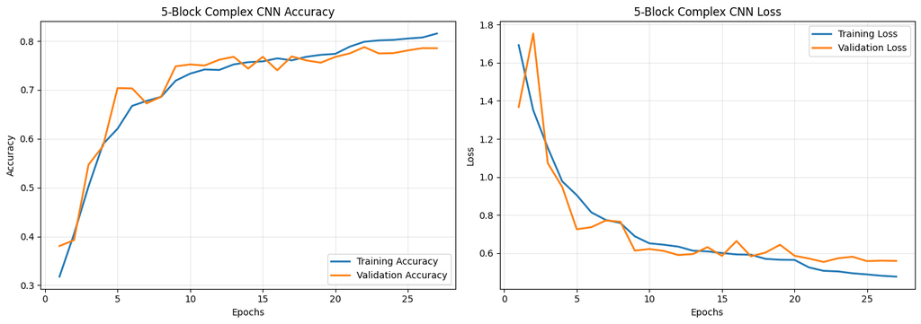

```python
import matplotlib.pyplot as plt

print("Evaluating Complex CNN on the Test Set...")
# Evaluate the model using the unseen grayscale test data
test_loss_complex, test_accuracy_complex = model_complex.evaluate(test_generator, verbose=1)

print(f"\n 5-Block Complex CNN Test Accuracy: {test_accuracy_complex * 100:.2f}%")
print(f"  5-Block Complex CNN Test Loss: {test_loss_complex:.4f}")

# Extract metrics from the training history
acc = history_complex.history['accuracy']
val_acc = history_complex.history['val_accuracy']
loss = history_complex.history['loss']
val_loss = history_complex.history['val_loss']
epochs_range = range(1, len(acc) + 1)

# Plotting the Training and Validation Curves
plt.figure(figsize=(14, 5))

# Accuracy Plot
plt.subplot(1, 2, 1)
plt.plot(epochs_range, acc, label='Training Accuracy', linewidth=2)
plt.plot(epochs_range, val_acc, label='Validation Accuracy', linewidth=2)
plt.title('5-Block Complex CNN Accuracy')
plt.xlabel('Epochs')
plt.ylabel('Accuracy')
plt.legend(loc='lower right')
plt.grid(alpha=0.3)

# Loss Plot
plt.subplot(1, 2, 2)
plt.plot(epochs_range, loss, label='Training Loss', linewidth=2)
plt.plot(epochs_range, val_loss, label='Validation Loss', linewidth=2)
plt.title('5-Block Complex CNN Loss')
plt.xlabel('Epochs')
plt.ylabel('Loss')
plt.legend(loc='upper right')
plt.grid(alpha=0.3)

plt.tight_layout()
plt.show()
```

### **Plotting the Confusion Matrix for the chosen final model**

```
Generating Predictions for the Confusion Matrix...
```

[output not shown]

```
2/2 ━━━━━━━━━━━━━━━━━━━━ 2s 55ms/step

Classification Report:
              precision    recall  f1-score   support

       happy       0.90      0.88      0.89        32
     neutral       0.74      0.81      0.78        32
         sad       0.77      0.75      0.76        32
    surprise       0.94      0.91      0.92        32

    accuracy                           0.84       128
   macro avg       0.84      0.84      0.84       128
weighted avg       0.84      0.84      0.84       128


Plotting Confusion Matrix...
```

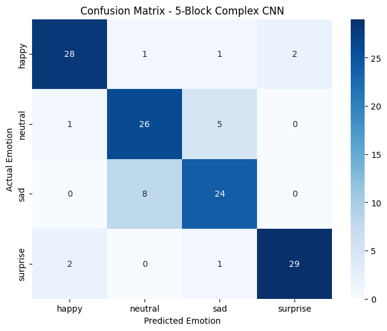

```python
import numpy as np
import seaborn as sns
from sklearn.metrics import confusion_matrix, classification_report
import matplotlib.pyplot as plt

print("Generating Predictions for the Confusion Matrix...")
# 1. Reset the test generator so it starts exactly at the beginning
test_generator.reset()

# 2. Get the model's raw probability predictions
predictions = model_complex.predict(test_generator, verbose=1)

# 3. Convert those probabilities into the final predicted class (0, 1, 2, or 3)
y_pred = np.argmax(predictions, axis=1)

# 4. Get the actual true labels from the generator
y_true = test_generator.classes

# 5. Extract the actual emotion names for our labels
class_names = list(test_generator.class_indices.keys())

# --- Print Classification Report ---
print("\nClassification Report:")
print(classification_report(y_true, y_pred, target_names=class_names))

# --- Plot the Confusion Matrix ---
print("\nPlotting Confusion Matrix...")
cm = confusion_matrix(y_true, y_pred)

plt.figure(figsize=(8, 6))
sns.heatmap(cm, annot=True, fmt='d', cmap='Blues',
            xticklabels=class_names, yticklabels=class_names)
plt.title('Confusion Matrix - 5-Block Complex CNN')
plt.ylabel('Actual Emotion')
plt.xlabel('Predicted Emotion')
plt.show()
```

### **Observations and Insights:**

- The tuned **5-Block Complex CNN** achieved strong overall performance on the test set, reaching **83.59% test accuracy** with a **test loss of 0.4933**. This indicates that the model generalized well to unseen facial-expression images.
- The model performed best on **surprise** and **happy**, with F1-scores of **0.92** and **0.89**, respectively. This suggests that these emotions have clearer and more distinctive facial patterns that the network can learn more reliably.
- Performance on **neutral** also improved substantially, with an F1-score of **0.78** and recall of **0.81**. However, the confusion matrix shows that some neutral expressions were still misclassified as **sad**, which confirms that these two classes remain visually similar.
- The **sad** class also showed much stronger performance than in the earlier models, with an F1-score of **0.76** and recall of **0.75**. Even so, it remained one of the more difficult expressions because subtle sad faces were still sometimes confused with neutral faces.
- Overall, the confusion matrix shows that most predictions lie along the diagonal, confirming that the model learned meaningful facial-expression features across all four classes. Compared with the earlier custom CNN versions, this tuned model provides a better balance between high overall accuracy and improved recognition of previously ambiguous classes.

### **Final Conclusion: The Tuned Custom CNN**

- **Performance Breakthrough:** The tuned Custom 5-Block CNN delivered the strongest result in the project, achieving **83.59% test accuracy** with a **test loss of 0.4933** on the final test set. This confirms that the deeper grayscale architecture, combined with stronger regularization, improved generalization beyond both the earlier custom CNNs and the transfer learning models.
- **Impact of Optimization:** The final model achieved a more balanced class-wise performance than the earlier architectures. The F1-scores reached **0.89** for **happy**, **0.78** for **neutral**, **0.76** for **sad**, and **0.92** for **surprise**, showing that the optimization strategy helped reduce the earlier weakness on subtle classes such as **sad** and **neutral**.
- **Final Verdict:** This final experiment shows that a native **grayscale custom CNN** is better suited to this low-resolution facial-expression dataset than heavier transfer learning models that require RGB input. The model achieved the highest overall accuracy and delivered stronger balance across all four emotion classes, making it the best final solution among the tested architectures.

## **Conclusion:**

## Comprehensive Model Performance Summary

Throughout this project, we tested multiple architectures ranging from lightweight custom CNNs to large transfer learning models on a 48x48 grayscale facial-expression dataset.

### 1. Overall Accuracy Comparison

| Model Architecture | Setup / Status | Training Accuracy | Validation Accuracy | Final Test Accuracy |
| --- | --- | --- | --- | --- |
| **EfficientNetB0** | Tuned (Mode Collapse, Random Guessing) | ~26.00% | ~25.00% | **25.00%** |
| **ResNet50V2** | Tuned (Spatial Degradation, Underfitting) | ~54.00% | ~57.00% | **57.03%** |
| **VGG16** | Tuned (Moderate Success, Shallowest Pre-trained) | ~58.00% | ~65.00% | **70.31%** |
| **Base 2-Block CNN** | Baseline (Native Scale, Shallow) | **~62.5%** | **~69.2%** | **69.53%** |
| **Custom 5-Block CNN** | Complex (Dropout, ReduceLROnPlateau) | ~72.00% | ~75.00% | **78.12%** |
| 🏆 **Final Custom CNN** | **Tuned (Batch Norm, Optimized Regularization)** | **~81.5%** | **~78.5%** | **83.59%** |

### 2. Classification Breakdown (F1-Scores by Emotion)

*This table shows how each model handled the four facial-expression classes, with particular attention to the difficult* *Sad vs. Neutral** distinction.*

| Model Architecture | Happy | Surprise | Neutral | Sad |
| --- | --- | --- | --- | --- |
| **VGG16 (Tuned)** | **0.78** | **0.84** | **0.58** | **0.60** |
| **Base 2-Block CNN** | **0.70** | **0.89** | **0.66** | **0.54** |
| **Custom 5-Block CNN** | **0.91** | **0.91** | **0.68** | **0.62** |
| 🏆 **Final Custom CNN** | **0.89** | **0.92** | **0.78** | **0.76** |

### Key Takeaways from the Data

1. **Transfer learning was not the best fit for this dataset.** EfficientNetB0 and ResNet50V2 performed poorly compared with the custom grayscale CNNs, suggesting that large RGB pre-trained models are not well suited to tiny 48x48 grayscale facial-expression images.
2. **Native grayscale modeling was far more effective.** The strongest-performing models were the custom CNNs built directly for 1-channel grayscale input, which preserved useful spatial information without adding unnecessary RGB redundancy.
3. **The ambiguity bottleneck was reduced substantially.** The final tuned CNN improved the **Sad** F1-score from **0.54** in the Base 2-Block CNN to **0.76**, while also lifting **Neutral** to **0.78**, showing a much better ability to separate subtle expressions.
4. **The final tuned CNN delivered the best overall result.** With **83.59% test accuracy** and balanced class-wise performance across all four emotions, it was the strongest architecture in the project and the most suitable final solution among the tested models.

### **Refined Insights: What are the most meaningful takeaways from the data?**

- **Structural Features Overpower Color (The RGB Penalty):** The most meaningful insight from this project is that facial emotion recognition in low-resolution environments depends entirely on **structural spatial features** (edges, shadows, eye shape, mouth curvature) rather than color. Forcing the dataset into 3-channel RGB formats for the transfer learning models wasted computational power and diluted the actual signal, proving that a native 1-channel Grayscale approach is vastly superior for this domain.
- **The Threat of Spatial Degradation:** Image resolution plays an absolute dictating role in model architecture success. Massive transfer learning architectures (ResNet, EfficientNet) failed not because they are "bad" models, but because their deep pooling layers mathematically crushed our tiny 48x48 images into unreadable noise before classification.
- **The Ambiguity Bottleneck Can Be Tuned:** Facial expressions are inherently ambiguous (e.g., a resting face looks very similar to a sad face). We discovered that simply adding more convolutional layers is not enough to separate these classes. It requires strict mathematical stabilization—specifically using **Batch Normalization** to maintain feature distribution and dynamic learning rates (`ReduceLROnPlateau`) to make microscopic weight adjustments in the final epochs.

### **Proposal for the Final Solution Design**

**What model do you propose to be adopted? Why is this the best solution?**

We formally propose the **Tuned 5-Block Custom CNN (Grayscale)** as the final solution for deployment.

### **Future Recommendations for Continuous Improvement**

While the current solution is highly robust, we recommend the following steps for future iterations or production scaling:

1. **Data-Centric AI (Facial Landmark Cropping):** While our CNN learned spatial features well, future pipelines could utilize libraries like MediaPipe or OpenCV to actively crop and isolate specific high-value facial landmarks (eyes and mouths) before passing them to the network, further removing background noise.
2. **Edge Device Deployment (Quantization):** Because our winning model is a lightweight Custom CNN, it is a perfect candidate for **TensorFlow Lite conversion**. By applying post-training quantization (converting 32-bit floats to 8-bit integers), this model could be deployed directly onto low-power edge devices (like mobile phones, webcams, or IoT smart cameras) for real-time, zero-latency emotion tracking.
3. **Real-World Video Integration:** The model was trained on static 48x48 frames. The next logical phase of this project would be to build an OpenCV inference script that captures a live webcam feed, runs a Haar Cascade face-detector to isolate the face, downsizes it to 48x48 grayscale, and passes it to our CNN for real-time video emotion classification.

# Facial Emotion Detection - Report

# Executive summary

This project developed and evaluated deep learning models for facial emotion detection using a 48x48 grayscale facial image dataset with four classes: happy, neutral, sad, and surprise. The main objective was to identify a model that could achieve strong predictive performance on unseen data while remaining practical for real-world deployment.

The most important finding from the analysis is that custom grayscale CNNs performed better than transfer learning models on this dataset. The experiments showed that models designed specifically for small grayscale inputs preserved facial structure more effectively than larger RGB-based pre-trained architectures, which added complexity without improving useful signal for this problem.

Among all evaluated models, the final proposed model is the Tuned 5-Block Custom CNN (Grayscale). This model achieved the best overall performance, with 83.59% final test accuracy and a test loss of 0.4933, outperforming the Base 2-Block CNN at 69.53%, the standard Custom 5-Block CNN at 78.12%, VGG16 at 70.31%, ResNet50V2 at 57.03%, and EfficientNetB0 at 25.00%.

The final model also produced the strongest balance across emotion classes. Its F1-scores were 0.89 for happy, 0.78 for neutral, 0.76 for sad, and 0.92 for surprise, indicating that the optimized architecture substantially improved the recognition of subtle expressions such as sad and neutral while maintaining excellent performance on the clearer classes.

# Problem Summary

Facial emotion detection is an important computer vision problem because human facial expressions contain useful information for decision-making in areas such as human-computer interaction, customer service, education, healthcare, and security. Automatically identifying emotions can help systems respond more intelligently and consistently in situations where manual observation is subjective, time-consuming, or difficult to scale.

The objective of this project was to build a deep learning model that could classify facial images into four emotion categories: happy, neutral, sad, and surprise. The task was formulated as a multi-class image classification problem using train, validation, and test image datasets, with the final aim of identifying the best-performing architecture for unseen data.

A key challenge in this problem is that the dataset consists of 48x48 grayscale images, which contain limited detail and make subtle expression separation difficult, especially for similar classes such as sad and neutral. This created a strong need for a model that could preserve fine facial structure while remaining robust enough to generalize beyond the training set.

# Solution Design

To solve this problem, multiple deep learning architectures were evaluated and compared. These included a Base 2-Block CNN, a Custom 5-Block CNN, and three transfer learning models: VGG16, ResNet50V2, and EfficientNetB0. The goal of this staged design was to understand whether increasing model complexity or using transfer learning would improve performance on this low-resolution grayscale dataset.

The final proposed solution is the Tuned 5-Block Custom CNN (Grayscale). This model was selected because it was specifically designed for 48x48 1-channel input and optimized with regularization strategies such as batch normalization, dropout, and improved tuning of the classifier head.

The final model outperformed all other tested architectures. The Base 2-Block CNN achieved 69.53% test accuracy, the standard 5-Block CNN achieved 78.12%, VGG16 achieved 70.31%, ResNet50V2 achieved 57.03%, and EfficientNetB0 collapsed to 25.00%, while the final tuned custom CNN improved performance further to 83.59%.

The design choice was justified by the structure of the dataset itself. Since the images were already grayscale, forcing them into RGB format for transfer learning added no new signal and increased computational burden, while deeper transfer learning architectures also lost important spatial detail through repeated downsampling

# Analysis and Key Insights

The project results show a clear and consistent pattern: native grayscale custom CNNs were more effective than transfer learning models on this dataset. This indicates that for low-resolution facial expression recognition, preserving structural spatial patterns such as edges, contours, shadows, and mouth-eye geometry is more useful than applying large RGB pre-trained architectures originally designed for very different image domains.

The standard 5-Block CNN already demonstrated a major improvement over the baseline model, increasing test accuracy from 69.53% to 78.12%. This showed that deeper convolutional feature extraction improved the model’s ability to recognize more complex and subtle facial patterns.

The final tuned model pushed this further by improving both overall performance and class balance. In particular, the difficult sad class improved from an F1-score of 0.54 in the Base 2-Block CNN to 0.76 in the Final Custom CNN, while neutral improved from 0.66 to 0.78. This confirms that the tuning strategy significantly reduced the earlier ambiguity bottleneck between subtle facial expressions.

Transfer learning models were not suitable for this task. VGG16 performed moderately at 70.31%, but ResNet50V2 fell to 57.03%, and EfficientNetB0 experienced complete mode collapse at 25.00%, effectively reducing to random-guess baseline performance in this balanced four-class problem.

Overall, the final tuned custom CNN provided the strongest combination of accuracy, generalization, and computational practicality. These findings support the conclusion that model architecture should be chosen according to the nature of the input data rather than assuming that larger pre-trained networks are automatically superior.

## Accuracy Comparision of Models Used

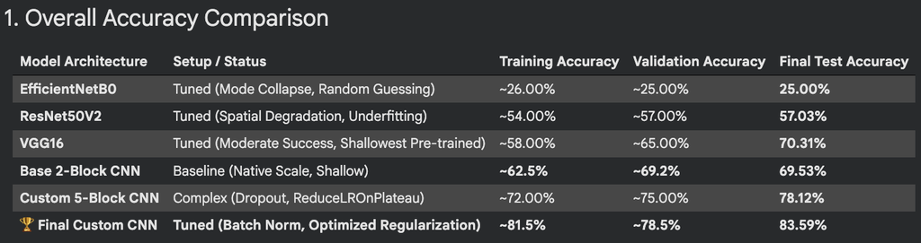

## Classification Report and Confusion Matrix of the selected 5 Block Complex CNN

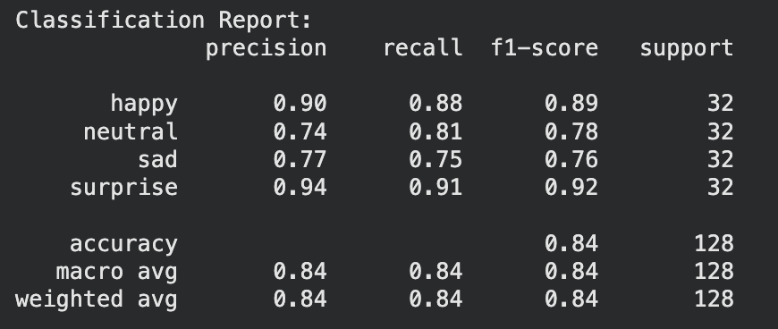

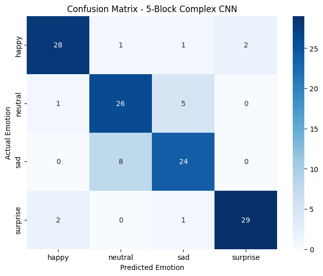

## Accuracy and Loss Graphs of the selected 5 Block Complex CNN

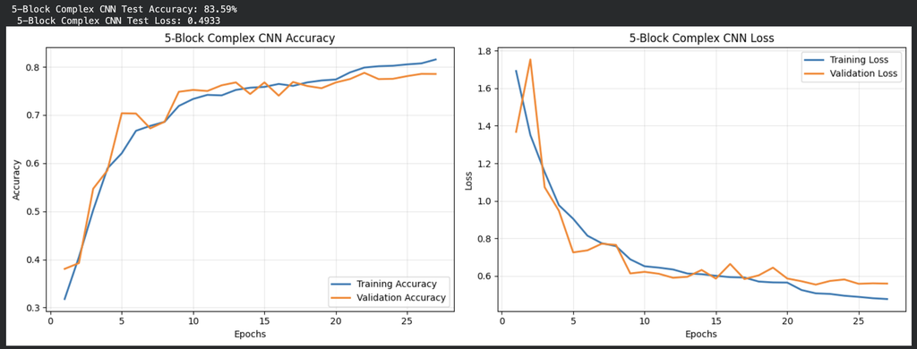

# Recommendations for Implementation

- Adopt the **Tuned 5-Block Custom CNN (Grayscale)** as the final implementation model because it achieved the highest final test accuracy and the best balance across the four emotion classes.
- Deploy the model within a lightweight preprocessing and inference pipeline that includes face detection, grayscale conversion, resizing to 48x48, and final emotion classification for real-time use cases such as webcams, mobile systems, kiosks, and edge-camera environments.
- Improve preprocessing through facial landmark-based cropping or focused face-region extraction using tools such as OpenCV or MediaPipe to isolate key regions like the eyes and mouth before classification.
- Optimize the model for low-power deployment using TensorFlow Lite conversion and post-training quantization to reduce memory usage and improve inference speed on smartphones, IoT devices, and embedded platforms.
- Account for implementation costs, including the additional engineering work required for integration, validation, deployment testing, and production monitoring.
- Recognize key risks and challenges, especially the difficulty of separating subtle expressions such as sad and neutral, along with possible performance drops under changes in lighting, pose, blur, and occlusion.
- Address privacy and security concerns related to facial-image capture, storage, and processing before any real-world rollout.
- Conduct further analysis through real-time video testing, broader dataset expansion, fairness validation across user groups, and evaluation under practical deployment conditions.
- Plan for associated system improvements such as stronger face detection, low-light handling, motion-blur robustness, and secure data governance as part of future implementation design.